# CITS4009 - Project 2

Sergio Banchero - Michael Wheeler

## Introduction

The dataset chosen is the Global Terrorist Database (GTD) and is located on Kaggle at https://www.kaggle.com/START-UMD/gtd. The GTD is an open-source database that contains collected information on terrorist attacks around the world from 1970 through 2017. The GTD has 137 features and over 180,000 observations.

Load libraries

```r
library(ggplot2)
library(gridExtra)
library(dplyr)
library(ggthemes)
library(numform)
library(timeDate)
library(lubridate)
library(reshape2)
library(ca)
library(tidyr)
library(ape)
library(knitr)
library(ROCR)
library(rpart)
library(grid)
library(gridExtra)
library(tidyverse)
library(data.table)
library(xgboost)
library(vtreat)
```

Setting up a plotting theme so that all charts look coherent

```r
cits4009_theme <- theme_few() + # Theme based on S. Few's "Practical Rules for Using Color in Charts"
                  theme(plot.title = element_text(color = "darkred")) +
                  theme(strip.text.x = element_text(size = 14, colour = "#202020")) +
                  theme(plot.margin=margin(10,30,10,30))

cits4009_map_theme <- cits4009_theme +
                      theme(panel.grid = element_blank(),
                            panel.border = element_blank(),
                            legend.position="top", legend.direction = 'horizontal',
                            axis.title.x=element_blank(),
                            axis.text.x=element_blank(),
                            axis.ticks.x=element_blank(),
                            axis.title.y=element_blank(),
                            axis.text.y=element_blank(),
                            axis.ticks.y=element_blank())

cits4009_radar_theme <- theme(plot.title = element_text(color = "darkred", size = 14, hjust = 0.5)) +
                  theme(strip.text.x = element_text(size = 12, colour = "#202020")) +
                  theme(plot.margin=margin(1,1,1,1))
```

Load the main data

```r
data.path <- './data/globalterrorismdb_0718dist.csv'
attacks <- read.csv(data.path)
```

## Part 1 - Classification

### Choose the response (target) variable

The response variable we have chosen is the amount of people that have been affect by an incident. The variable wasn’t present in the database, so we created the variable by summing the number of people wounded and number of people killed in an incidence. We have focused on this as a target variable to help classify terror attacks as either people will be affected by an attack or they will not be. The labels we assigned to this variable are [0.1) for no-one affect or [1,Inf] for people have been wounded or killed. Our hope is to create a classification model that, with a variety of explanatory variables, will be able to assess if an incident will involve extra attention due to casualties being involved.

Create a categorical “target” variable. Were there killed or injured people?

```r
attacks <-  attacks %>% mutate(affected = nwound + nkill ) %>%
            mutate(aff_val = cut(affected, breaks = c(0, 1, Inf), include.lowest=T, right=F)) %>% # this is for "binary" classification
            filter(!is.na(aff_val)) # keep only non-na values
table(attacks$aff_val)
```

```
##
##   [0,1) [1,Inf]
##   63297  101520
```

```r
round(prop.table(table(attacks$aff_val)), 2)
```

```
##
##   [0,1) [1,Inf]
##    0.38    0.62
```

### Selecting variables

Creating a selection of “candidate” columns as predictors and the target column. We want to look at a variety of variables that could identify if any has been affected by the event. We use the code book located at https://www.start.umd.edu/gtd/downloads/Codebook.pdf to make an informed decision about the variable we could use. The main objective was to chose variables that service operator could have available to them, and then using the model created to make an informed decision on the amount of people affected. For example, we have include the ‘success’ metric because if the incident was foiled less people will be affected, however, even successful incidents don’t always have a human toll.

```r
candidate.columns <- c("iyear","imonth","iday","extended",
  "country_txt","region_txt","latitude","longitude",
  "crit1","crit2","crit3",
  "doubtterr","alternative_txt","multiple",
  "success","suicide",
  "attacktype1_txt","attacktype2_txt","attacktype3_txt",
  "targtype1_txt","targsubtype1_txt","natlty1_txt",
  "targtype2_txt","targsubtype2_txt","natlty2_txt",
  "targtype3_txt","targsubtype3_txt","natlty3_txt",
  "gname",
  "nperps","nperpcap",
  "claimed", "claimmode_txt",
  "weaptype1_txt",#"weaptype2_txt","weaptype3_txt","weaptype4_txt",
  "property",
  "nhours"
  )
outcome <- 'aff_val'
pos.label <- "[1,Inf]"
```

```r
data <- attacks[,c(outcome, candidate.columns)]
```

Idenifying numerical data within the selected variables.

```r
col_num <- which(colnames(data) %in% c("nhours","imonth","latitude", "longitude", "iday", "iyear", "nperps"))
```

Converting the boolean variables to factor.

```r
data[,-col_num] <- lapply(data[,-col_num] , factor)
```

### Checking the incidents

See the incidents as a cummulative by year Below we can see that there has been an escalation of incidents as we progress throught the years (the slope is increasing). Both the number of non-people affected and people affected incidents have increased in their occurrence. It is also important to note that the class balance is also shifting with time, which makes the prediction problem more complex.

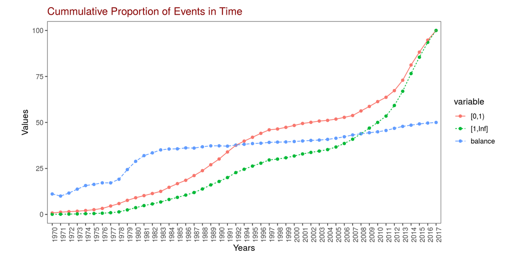

```r
incidents_per_year <- as.matrix(table(data[,outcome], data$iyear))
cummulative_ipy <- as.data.frame(t(t(apply(incidents_per_year,1,cumsum))/apply(incidents_per_year,1,sum)*100))
cummulative_ipy$year <- rownames(cummulative_ipy)
cummulative_ipy$balance <- 100*cummulative_ipy$`[1,Inf]`/(cummulative_ipy$`[0,1)`+cummulative_ipy$`[1,Inf]`)
ggplot(melt(cummulative_ipy), aes(x=year,y=value,group=variable,colour=variable)) +
  cits4009_theme +
  labs(x = "Years", y = "Values", title= "Cummulative Proportion of Events in Time")+
  theme(axis.text.x = element_text(angle = 90, hjust = 1)) +
  geom_point()+
  geom_line(aes(lty=variable))
```

### Splitting the data

Split into train-calibration-test sets, this split is based on the years. We will be creating a model base on data prior to 2013 and using data post 2015 to validate our models. The reasoning behind this split is our model will be designed to predict if ‘future’ events can be accurately categorised.

```r
split.train.cal.test <- function(x, split.column='iyear', train.split.value=2013, cal.split.value=2015){
  rvalue <- x[,split.column]
  list( x[rvalue <= train.split.value, ],
        x[rvalue > train.split.value & rvalue <= cal.split.value, ],
        x[rvalue > cal.split.value, ])
}

splits <- split.train.cal.test(data, split.column='iyear', train.split.value=2013, cal.split.value=2015)
dTrain <- splits[[1]]
dCal <- splits[[2]]
dTest <- splits[[3]]
```

```r
lapply(splits,nrow)
```

```
## [[1]]
## [1] 114148
##
## [[2]]
## [1] 28440
##
## [[3]]
## [1] 22229
```

Splitting the data into Categorical and numerical variables

```r
catVars <- candidate.columns[sapply(dTrain[,candidate.columns],class) %in% c('factor','character')]
numericVars <- candidate.columns[sapply(dTrain[,candidate.columns],class) %in% c('numeric','integer')]
```

```r
numericVars
```

```
## [1] "iyear"     "imonth"    "iday"      "latitude"  "longitude" "nperps"
## [7] "nhours"
```

```r
catVars
```

```
##  [1] "extended"         "country_txt"      "region_txt"
##  [4] "crit1"            "crit2"            "crit3"
##  [7] "doubtterr"        "alternative_txt"  "multiple"
## [10] "success"          "suicide"          "attacktype1_txt"
## [13] "attacktype2_txt"  "attacktype3_txt"  "targtype1_txt"
## [16] "targsubtype1_txt" "natlty1_txt"      "targtype2_txt"
## [19] "targsubtype2_txt" "natlty2_txt"      "targtype3_txt"
## [22] "targsubtype3_txt" "natlty3_txt"      "gname"
## [25] "nperpcap"         "claimed"          "claimmode_txt"
## [28] "weaptype1_txt"    "property"
```

Here is a function that is used for Single variable predictions for categorical variables.

```r
mkPredC <- function(outCol,varCol,appCol, pos=pos.label) {
  pPos <- sum(outCol==pos)/length(outCol)
  naTab <- table(as.factor(outCol[is.na(varCol)]))
  pPosWna <- (naTab/sum(naTab))[pos]
  vTab <- table(as.factor(outCol),varCol)
  pPosWv <- (vTab[pos,]+1.0e-3*pPos)/(colSums(vTab)+1.0e-3)
  pred <- pPosWv[appCol]
  pred[is.na(appCol)] <- pPosWna
  pred[is.na(pred)] <- pPos
  pred
}
```

```r
for(v in catVars) {
  pii <- paste('pred',v,sep='')
  dTrain[,pii] <- mkPredC(dTrain[,outcome], dTrain[,v], dTrain[,v])
  dCal[,pii] <- mkPredC(dTrain[,outcome], dTrain[,v], dCal[,v])
  dTest[,pii] <- mkPredC(dTrain[,outcome], dTrain[,v], dTest[,v])
}
```

Evaluate AUC for the single-variable models (categoricals)

```r
## ------------------------------------------------------------------------
calcAUC <- function(predcol, outcol, pos=pos.label) {
  perf <- performance(prediction(predcol, outcol==pos),'auc')
  as.numeric(perf@y.values)
}
```

```r
for(v in catVars) {
  pii <- paste('pred',v,sep='')
  aucTrain <- calcAUC(dTrain[,pii],dTrain[,outcome])
  if(aucTrain>=0.54) {
    aucCal <- calcAUC(dCal[,pii],dCal[,outcome])
    print(sprintf(
      "%s, trainAUC: %4.3f calibrationAUC: %4.3f",
      pii, aucTrain, aucCal))
  }
}
```

```
## [1] "predcountry_txt, trainAUC: 0.730 calibrationAUC: 0.692"
## [1] "predregion_txt, trainAUC: 0.682 calibrationAUC: 0.588"
## [1] "preddoubtterr, trainAUC: 0.569 calibrationAUC: 0.524"
## [1] "predalternative_txt, trainAUC: 0.551 calibrationAUC: 0.524"
## [1] "predmultiple, trainAUC: 0.563 calibrationAUC: 0.546"
## [1] "predsuccess, trainAUC: 0.556 calibrationAUC: 0.637"
## [1] "predattacktype1_txt, trainAUC: 0.743 calibrationAUC: 0.669"
## [1] "predtargtype1_txt, trainAUC: 0.724 calibrationAUC: 0.681"
## [1] "predtargsubtype1_txt, trainAUC: 0.787 calibrationAUC: 0.731"
## [1] "prednatlty1_txt, trainAUC: 0.729 calibrationAUC: 0.686"
## [1] "predgname, trainAUC: 0.681 calibrationAUC: 0.607"
## [1] "prednperpcap, trainAUC: 0.593 calibrationAUC: 0.508"
## [1] "predclaimed, trainAUC: 0.588 calibrationAUC: 0.464"
## [1] "predweaptype1_txt, trainAUC: 0.717 calibrationAUC: 0.640"
## [1] "predproperty, trainAUC: 0.640 calibrationAUC: 0.561"
```

From the list of single categorical variables, it can be seen that there is few promising variables. For example, targetsubtype1_txt’s calibration and training AUCs scored above 0.73.

Build single variable predictions for numerical variables. Evaluate AUC for the single-variable models (numericals)

```r
## ------------------------------------------------------------------------
mkPredN <- function(outCol,varCol,appCol) {
  cuts <- unique(as.numeric(quantile(varCol, probs=seq(0, 1, 0.1), na.rm=T)))
  varC <- cut(varCol, cuts)
  appC <- cut(appCol, cuts)
  mkPredC(outCol, varC, appC)
}
```

```r
for(v in numericVars) {
  pii<-paste('pred',v,sep='')
  dTrain[,pii] <- mkPredN(dTrain[,outcome], dTrain[,v], dTrain[,v])
  dTest[,pii] <- mkPredN(dTrain[,outcome], dTrain[,v], dTest[,v])
  dCal[,pii] <- mkPredN(dTrain[,outcome], dTrain[,v], dCal[,v])
  aucTrain <- calcAUC(dTrain[,pii],dTrain[,outcome])

  if(aucTrain>=0.5) {
    aucCal<-calcAUC(dCal[,pii],dCal[,outcome])
    print(sprintf(
      "%s, trainAUC: %4.3f calibrationAUC: %4.3f",
      pii,aucTrain,aucCal))
  }
}
```

```
## [1] "prediyear, trainAUC: 0.612 calibrationAUC: 0.500"
## [1] "predimonth, trainAUC: 0.515 calibrationAUC: 0.509"
## [1] "prediday, trainAUC: 0.506 calibrationAUC: 0.503"
## [1] "predlatitude, trainAUC: 0.657 calibrationAUC: 0.632"
## [1] "predlongitude, trainAUC: 0.669 calibrationAUC: 0.596"
## [1] "prednperps, trainAUC: 0.545 calibrationAUC: 0.547"
## [1] "prednhours, trainAUC: 0.507 calibrationAUC: 0.500"
```

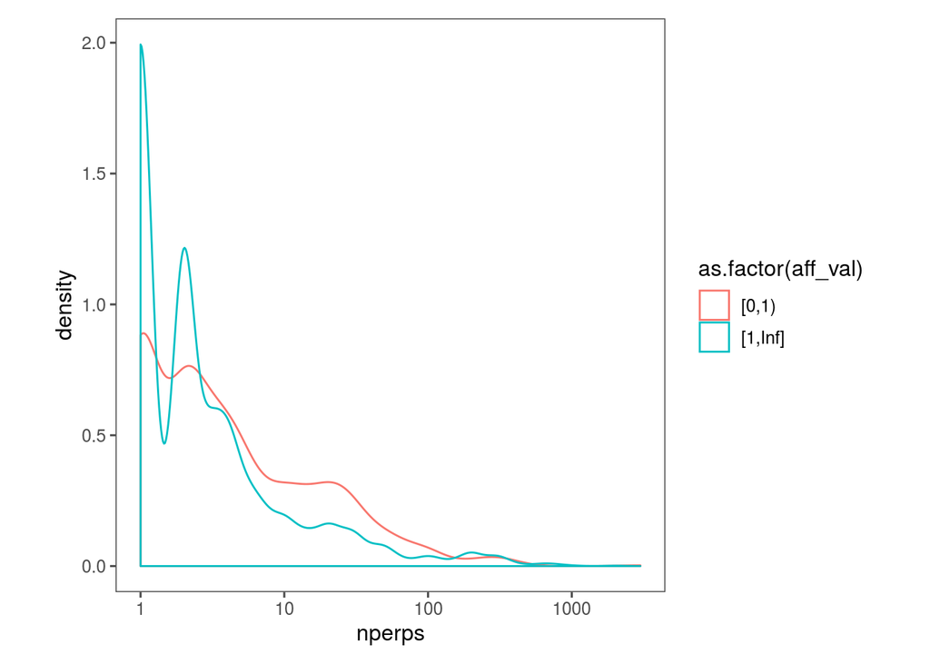

```r
## frequency plots for quantitative variables, split by status
ggplot(data=dCal) +
  geom_density(aes(x=nperps,color=as.factor(aff_val))) +
  scale_x_continuous(trans='log10') +
  cits4009_theme
```

We see that for the number of perpetrators, the distribution of is different for both classes. The chart indicates that if the numer of perpetrators is smaller, it is more likely to have affected people.

Store this results in a dataframe for easier reference.

```r
all.vars <- c(catVars, numericVars)
models.auc <- data.frame(model.type = 'univariate',
                         model.name = all.vars,
                         train.auc = sapply(all.vars, function(v){pii <- paste('pred',v,sep=''); calcAUC(dTrain[,pii], dTrain[,outcome])}),
                         cal.auc = sapply(all.vars, function(v){pii <- paste('pred',v,sep=''); calcAUC(dCal[,pii],dCal[,outcome])}))
kable(models.auc[order(-models.auc$cal.auc), ])
```

|  | model.type | model.name | train.auc | cal.auc |
| --- | --- | --- | --- | --- |
| targsubtype1_txt | univariate | targsubtype1_txt | 0.7874123 | 0.7310866 |
| country_txt | univariate | country_txt | 0.7299450 | 0.6919072 |
| natlty1_txt | univariate | natlty1_txt | 0.7288547 | 0.6858629 |
| targtype1_txt | univariate | targtype1_txt | 0.7239635 | 0.6811225 |
| attacktype1_txt | univariate | attacktype1_txt | 0.7431663 | 0.6689829 |
| weaptype1_txt | univariate | weaptype1_txt | 0.7169374 | 0.6401274 |
| success | univariate | success | 0.5559894 | 0.6369811 |
| latitude | univariate | latitude | 0.6572708 | 0.6318364 |
| gname | univariate | gname | 0.6812750 | 0.6066655 |
| longitude | univariate | longitude | 0.6692680 | 0.5958632 |
| region_txt | univariate | region_txt | 0.6816597 | 0.5880913 |
| property | univariate | property | 0.6398837 | 0.5611750 |
| nperps | univariate | nperps | 0.5454176 | 0.5465268 |
| multiple | univariate | multiple | 0.5627258 | 0.5461857 |
| claimmode_txt | univariate | claimmode_txt | 0.5161580 | 0.5445000 |
| targsubtype2_txt | univariate | targsubtype2_txt | 0.5225955 | 0.5384573 |
| natlty2_txt | univariate | natlty2_txt | 0.5225847 | 0.5370026 |
| targtype2_txt | univariate | targtype2_txt | 0.5208833 | 0.5366430 |
| suicide | univariate | suicide | 0.5201463 | 0.5330890 |
| alternative_txt | univariate | alternative_txt | 0.5508023 | 0.5242207 |
| doubtterr | univariate | doubtterr | 0.5685889 | 0.5236521 |
| crit3 | univariate | crit3 | 0.5390591 | 0.5224444 |
| extended | univariate | extended | 0.5132159 | 0.5117009 |
| attacktype2_txt | univariate | attacktype2_txt | 0.5113238 | 0.5115336 |
| imonth | univariate | imonth | 0.5147945 | 0.5091643 |
| nperpcap | univariate | nperpcap | 0.5926958 | 0.5078825 |
| iday | univariate | iday | 0.5058672 | 0.5032377 |
| targsubtype3_txt | univariate | targsubtype3_txt | 0.5032834 | 0.5026888 |
| natlty3_txt | univariate | natlty3_txt | 0.5031419 | 0.5023692 |
| targtype3_txt | univariate | targtype3_txt | 0.5025470 | 0.5023200 |
| crit2 | univariate | crit2 | 0.5030928 | 0.5009711 |
| attacktype3_txt | univariate | attacktype3_txt | 0.5006913 | 0.5008552 |
| crit1 | univariate | crit1 | 0.5043503 | 0.5000274 |
| iyear | univariate | iyear | 0.6121511 | 0.5000000 |
| nhours | univariate | nhours | 0.5072017 | 0.4997385 |
| claimed | univariate | claimed | 0.5875969 | 0.4644983 |

Perform feature selection with log likelihood

```r
## ------------------------------------------------------------------------
# Define a convenience function to compute log likelihood.
logLikelyhood <- function(outCol, predCol, pos=pos.label) {
  sum(ifelse(outCol==pos, log(predCol), log(1-predCol)))
}
```

```r
# Compute the base rate of a saturation model
baseRateCheck <- logLikelyhood(dCal[,outcome],  sum(dCal[,outcome]==pos.label)/length(dCal[,outcome]) )

## ------------------------------------------------------------------------
selPredVars <- c()
selVars <- c()
minStep <- 1000

for(v in catVars) {
  pii <- paste('pred',v,sep='')
  liCheck <- 2*((logLikelyhood(dCal[,outcome],dCal[,pii])
                 - baseRateCheck))
  if(liCheck>minStep) {
    print(sprintf("%s, calibrationScore: %g",pii,liCheck))
    selPredVars <- c(selPredVars,pii)
    selVars <- c(selVars, v)
  }
}
```

```
## [1] "predcountry_txt, calibrationScore: 2636.19"
## [1] "predregion_txt, calibrationScore: 1001.63"
## [1] "predsuccess, calibrationScore: 2365.59"
## [1] "predattacktype1_txt, calibrationScore: 2121.42"
## [1] "predtargtype1_txt, calibrationScore: 3405.21"
## [1] "predtargsubtype1_txt, calibrationScore: 4432.33"
## [1] "prednatlty1_txt, calibrationScore: 2390.77"
## [1] "predweaptype1_txt, calibrationScore: 1613.07"
```

```r
## ------------------------------------------------------------------------

for(v in numericVars) {
  pii <- paste('pred',v,sep='')
  liCheck <- 2*((logLikelyhood(dCal[,outcome],dCal[,pii])
                 - baseRateCheck) - 1)
  if(liCheck>=minStep) {
    print(sprintf("%s, calibrationScore: %g", pii,liCheck))
    selPredVars <- c(selPredVars,pii)
    selVars <- c(selVars, v)
  }
}
```

```
## [1] "predlatitude, calibrationScore: 1355.84"
```

```r
print(sprintf("%d variables selected",length(selVars)))
```

```
## [1] "9 variables selected"
```

Using the log likelihood we have been able to select 9 variables for a model.

### Evaluation of Models

The function below has been created evaluation of the different models we will create. The the function will return an ROC plot, prediction distribution plot, precision/recall plots, a confusion matrix and a null model’s log likelihood.

```r
evaluate_performance <- function(predictions, true.values, do.print=TRUE, threshold.value=0.5, pos=pos.label){
  eval.auc <- calcAUC(predictions, true.values)

  if(do.print){
    # ROC plot
    predObj <- prediction(predictions, true.values)
    perf <- performance(predObj, "tpr", "fpr")
    #plot(performance(predObj, "tpr", "fpr"))
    #abline(0, 1, lty = 2)
    roc.df <- data.frame('fpr'=unlist(perf@x.values),
                   'tpr'=unlist(perf@y.values),
                   'threshold'=unlist(perf@alpha.values))

    p <- ggplot(roc.df, aes(x=fpr, y=tpr))+
      geom_line() +
      geom_abline(intercept = 0, slope = 1, linetype='dashed') +
      cits4009_theme
    print(p)

    # prediction distribution plot
    p <- ggplot(data.frame(predictions=predictions,  true.values=true.values),
          aes(x=predictions, color=true.values, linetype=true.values)) +
          geom_density()  +
          labs(y = "True Positive Rate", x = "False Positive Rate") +
          cits4009_theme

    print(p)

    # precision/recall plot
    precObj <- performance(predObj, measure="prec")
    recObj <- performance(predObj, measure="rec")
    precision <- (precObj@y.values)[[1]]
    prec.x <- (precObj@x.values)[[1]]
    recall <- (recObj@y.values)[[1]]
    rocFrame <- data.frame(threshold=prec.x,
                           precision=precision,
                           recall=recall)
    pnull <-mean(true.values==pos)

    p1 <- ggplot(rocFrame, aes(x=threshold)) +
    geom_line(aes(y=precision)) +
    coord_cartesian(xlim = c(0,1), ylim=c(0,1) )  + cits4009_theme
    p2 <- ggplot(rocFrame, aes(x=threshold)) +
    geom_line(aes(y=recall)) +
    coord_cartesian(xlim = c(0,1) ) + cits4009_theme
    grid.arrange(p1, p2, nrow = 2)

    # Confusion matrix table
    cat('Confusion Matrix')
    ctab.test <- table(pred=predictions > threshold.value, true.values=true.values)
    print(kable(ctab.test))

    # Log likelihood
    pNull <- mean(true.values==pos.label)
    model.ll <- sum(ifelse(true.values==pos.label, log(predictions), log(1-predictions)))
    null.model.ll <- sum(ifelse(true.values==pos.label, log(pNull), log(1-pNull)))
    print(paste('Model Log Likelihood:', model.ll))
    print(paste('Null Model Log Likelihood:', null.model.ll))

  }

  eval.auc
}

evaluate_and_log_model <- function(model.type, model.name, predictions.train, true.values.train, predictions.cal, true.values.cal){
  train.auc <- evaluate_performance(predictions.train, true.values.train, do.print = FALSE)
  cal.auc <- evaluate_performance(predictions.cal, true.values.cal, do.print = TRUE)
  result <- data.frame(model.type = model.type,
                         model.name = model.name,
                         train.auc = train.auc,
                         cal.auc = cal.auc)
  rownames(result) <- model.name
  models.auc <<- unique(rbind(models.auc, result))
  result
}
```

### Multivariate models

#### Decision Tree with all variables

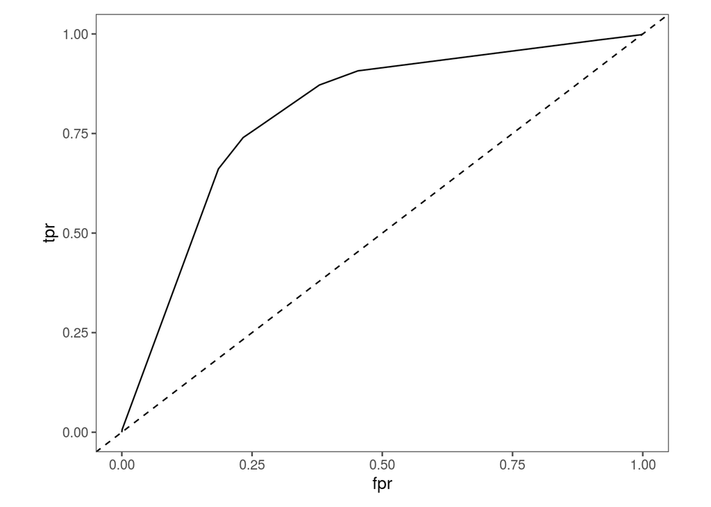

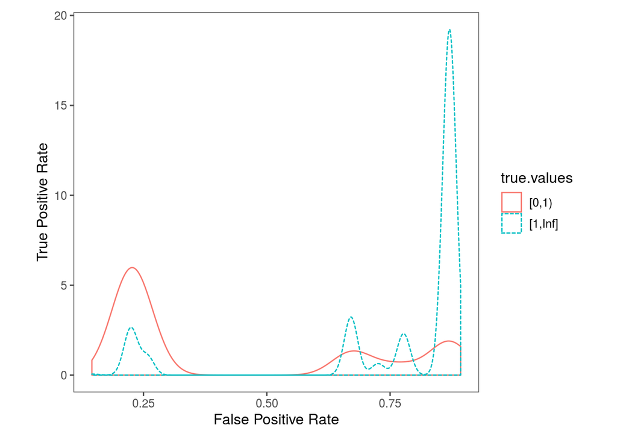

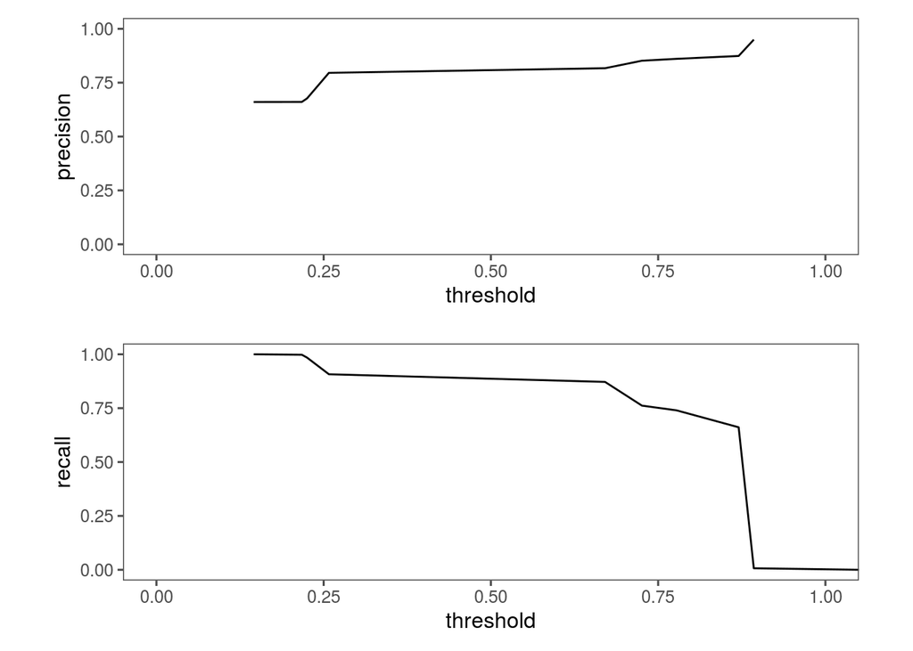

```
## Confusion Matrix
##
##          [0,1)   [1,Inf]
## ------  ------  --------
## FALSE     5997      2407
## TRUE      3665     16371
## [1] "Model Log Likelihood: -14088.6518173229"
## [1] "Null Model Log Likelihood: -18226.00342904"
```

|  | model.type | model.name | train.auc | cal.auc |
| --- | --- | --- | --- | --- |
| decision.tree.all.vars | multivariate | decision.tree.all.vars | 0.8246138 | 0.7998543 |

```r
fV <- paste(outcome,' ~ ', paste(c(catVars,numericVars), collapse=' + '), sep='')

decision.tree.all.vars <- rpart(fV, data=dTrain)

evaluate_and_log_model(model.type = 'multivariate',
                       model.name = 'decision.tree.all.vars',
                       predictions.train = predict(decision.tree.all.vars, newdata=dTrain)[,pos.label],
                       true.values.train = dTrain[,outcome],
                       predictions.cal = predict(decision.tree.all.vars, newdata=dCal)[,pos.label],
                       true.values.cal = dCal[,outcome])
```

The ‘Decision Tree with all variables’ model assigns a log likelihood of -14088.65 which is better than the Null model’s -18226.00. With an AUC of 0.82 (2.dp) for the training data and a value of 0.80 (2.dp) for the calibration data. This is a reasonable result, however, we would like further improvement. The ROC curve doesn’t look very impressive, we will be looking for further improvement with our future models. The distribution of score broken up by known classes shows some areas of concern, it can be seen that the probabilities assignment has not been properly calibrated. The precision looks reasonable for the model, however, for our purpose we would be looking for a higher recall. If an incident is labelled [1,Inf] (people are wounded or killed) and the incident didn’t result in any wounding or deaths, this isn’t as concerning as if people are affected and it is label incorrectly [0,1).

#### Decision Tree with the selected variables

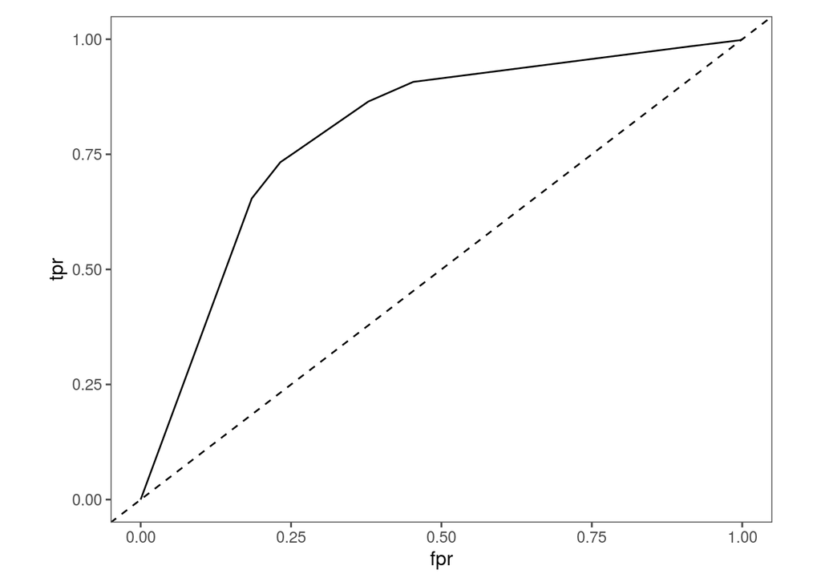

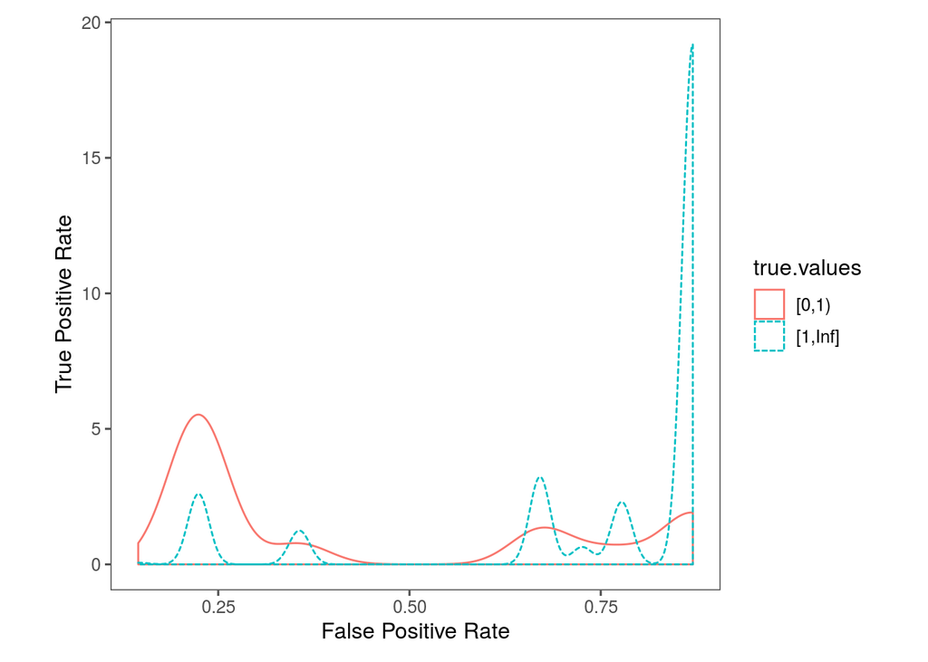

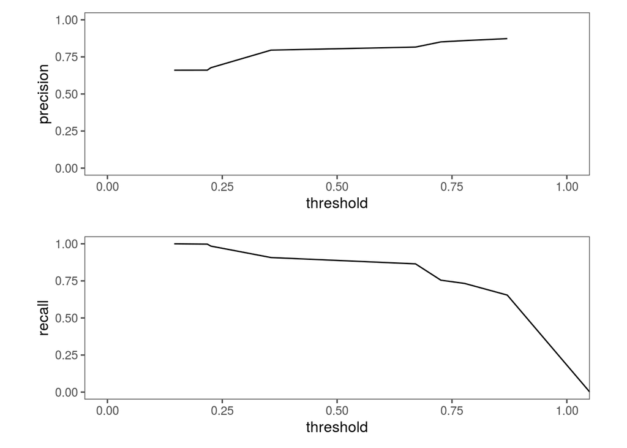

```
## Confusion Matrix
##
##          [0,1)   [1,Inf]
## ------  ------  --------
## FALSE     6004      2539
## TRUE      3658     16239
## [1] "Model Log Likelihood: -14083.4272977738"
## [1] "Null Model Log Likelihood: -18226.00342904"
```

|  | model.type | model.name | train.auc | cal.auc |
| --- | --- | --- | --- | --- |
| decision.tree.sel.vars | multivariate | decision.tree.sel.vars | 0.8233864 | 0.797573 |

```r
fV <- paste(outcome,' ~ ',  paste(selVars, collapse=' + '), sep='')

decision.tree.sel.vars <- rpart(fV, data=dTrain)

evaluate_and_log_model(model.type = 'multivariate',
                       model.name = 'decision.tree.sel.vars',
                       predictions.train = predict(decision.tree.sel.vars, newdata=dTrain)[,pos.label],
                       true.values.train = dTrain[,outcome],
                       predictions.cal = predict(decision.tree.sel.vars, newdata=dCal)[,pos.label],
                       true.values.cal = dCal[,outcome])
```

#### Logistic Regression model with selected variables

(note we use the mean of the target for each level by using selPredVars)

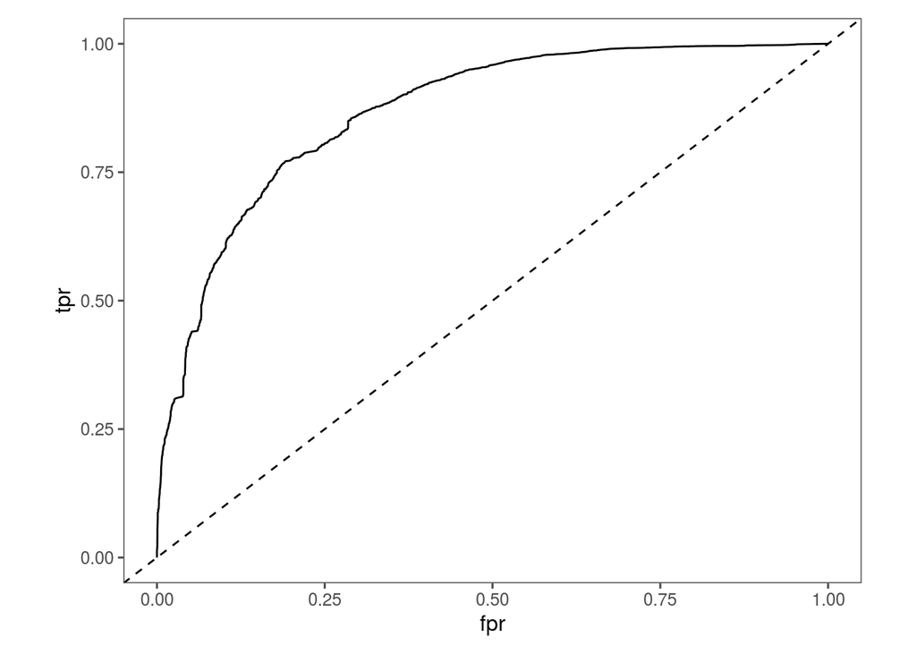

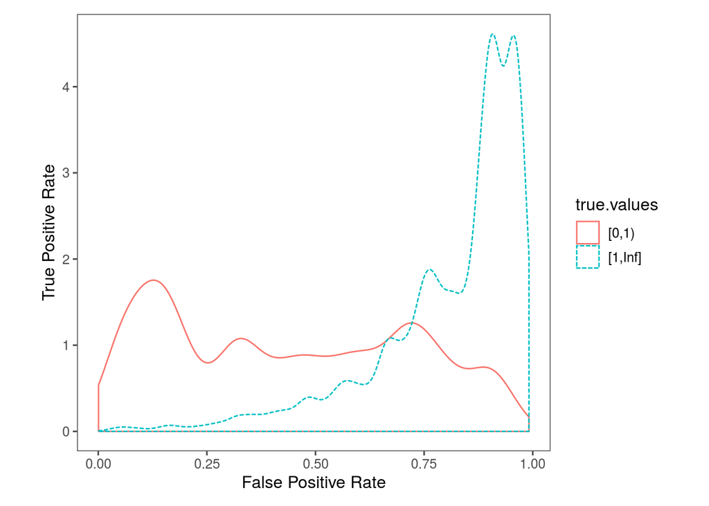

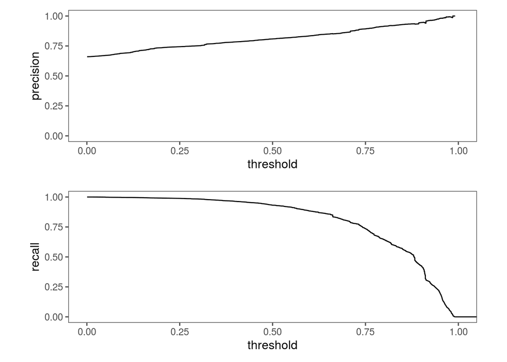

```
## Confusion Matrix
##
##          [0,1)   [1,Inf]
## ------  ------  --------
## FALSE     5535      1282
## TRUE      4127     17496
## [1] "Model Log Likelihood: -11943.0323497228"
## [1] "Null Model Log Likelihood: -18226.00342904"
```

|  | model.type | model.name | train.auc | cal.auc |
| --- | --- | --- | --- | --- |
| logreg.sel.pred.vars | multivariate | logreg.sel.pred.vars | 0.887463 | 0.8685504 |

```r
fV <- paste(outcome,' ~ ',  paste(selPredVars, collapse=' + '), sep='')

logreg.sel.pred.vars <- glm(fV, data=dTrain, family = binomial)

evaluate_and_log_model(model.type = 'multivariate',
                       model.name = 'logreg.sel.pred.vars',
                       predictions.train = predict(logreg.sel.pred.vars, newdata=dTrain, type = 'response'),
                       true.values.train = dTrain[,outcome],
                       predictions.cal = predict(logreg.sel.pred.vars, newdata=dCal, type = 'response'),
                       true.values.cal = dCal[,outcome])
```

The ‘Logistic Regression model with selected variables’ model assigns a log likelihood of -11943.03 which is better than the Null model’s -18226.00 and better than the two previous decision trees. With an AUC of 0.89 (2.dp) for the training data and a value of 0.87 (2.dp) for the calibration data. This has improved on the previous models. The ROC curve for this model has shown improvement compared to the two previous models. The distribution of score broken up by known classes has clearly improved from the 2 decision trees. The precision has shown improvement for the model and there is improvement with the recall.

### Feature engineering with combined One Hot Encoding (OHE)

Change the number of Months into a cyclic variable that Jan is closer to Dec rather that June

```r
new_att_mon <- subset(attacks, select = c("eventid","imonth"))

new_att_mon$cmon <- cos((new_att_mon$imonth-1)*pi/6)
new_att_mon$smon <- sin((new_att_mon$imonth-1)*pi/6)

new_att_mon$imonth <- NULL
```

Number of Hours and Number of perps created an unknown column for values

```r
new_att_perp <- subset(attacks, select = c("eventid","nperps"))

new_att_perp$unknown_perp <- 0

new_att_perp[, 2] [is.na(new_att_perp[, 2]) ] <- -99

i <- new_att_perp$nperps == -99 | new_att_perp$nperps== -9
new_att_perp$unknown_perp[i] <- 1
new_att_perp$nperps[i] <- 0
```

```r
new_att_hours <- subset(attacks, select = c("eventid","nhours"))

new_att_hours$unknown_hours <- 0

i <- is.na(new_att_hours$nhours)
new_att_hours$unknown_hours[i] <- 1
new_att_hours$nhours[i] <- 0
```

Function use for the one-hot encoding

```r
one_hot<- function(input, output, df_input, check_col, limit) {

  # for variables which have a larger number of factors (pre-selected)
  if (limit > 0){
    x <- as.data.frame(table(df_input[,check_col]))
    # create list of factor not greater than a given frequency
    y <- as.character(c())
    for(i in 1:nrow(x)){
      if(x$Freq[i] < limit){
        y <- c(y, as.character(x$Var1[i]))
      }
    }
  }
  # subsetting selected colunm(s)
  temp_df <- subset(df_input, select = input)

  #if the factor is in the list, change to Other to limit number of columns
  if (limit > 0){
    for (i in 2:ncol(temp_df)) {
      levels(temp_df[,i])[levels(temp_df[,i]) %in% y] <- 'Other'
    }
  }

  # one hot encode, keeping eventid for merging
  setDT(temp_df)
  temp_df <- dcast(setDT(melt(temp_df,id.vars = c("eventid")))[,ind:=1],eventid~value,value.var = "ind",fill=0)

  # label other column
  if("Other" %in% colnames(temp_df)){
    change <- paste('Other_',output,sep='')
    setnames(temp_df, "Other", change)
  }


  # change values to 1 that may be larger (occured more than once)
  for(j in 2:ncol(temp_df)){
     set(temp_df, i= which(temp_df[[j]] >1), j=j, value =1)
  }
  # check for overflow column
  if("V1" %in% colnames(temp_df)){
    temp_df$V1 <- NULL
  }
  # remove Unknown column (not needed)
  if("Unknown" %in% colnames(temp_df)){
    temp_df$Unknown <- NULL
  }
  # remove NA column (not needed)
  if("NA" %in% colnames(temp_df)){
    temp_df$`NA` <- NULL
  }

  temp_df

}
```

Selected columns to be one-hot encoded

```r
new_att_type <- one_hot(c("eventid","attacktype1_txt","attacktype2_txt","attacktype3_txt"),'type', attacks,  "empty", 0)
```

```
## Aggregate function missing, defaulting to 'length'
```

```r
new_att_wea <- one_hot(c("eventid", "weaptype1_txt","weaptype2_txt","weaptype3_txt","weaptype4_txt"),"wea",attacks, "empty", 0)
```

```
## Aggregate function missing, defaulting to 'length'
```

```r
new_att_targ <- one_hot(c("eventid", "targtype1_txt","targtype2_txt","targtype3_txt"),"targ",attacks,"empty", 0)
```

```
## Aggregate function missing, defaulting to 'length'
```

```r
new_att_claim <- one_hot( c("eventid", "claimmode_txt"),"claim",attacks,"empty", 0)
new_att_reg <- one_hot( c("eventid", "region_txt"),"reg",attacks,"empty", 0)
new_att_cou <- one_hot(c("eventid", "country_txt"),"cou",attacks, "country_txt", 3000)
new_att_gname <- one_hot(c("eventid", "gname"),"gname",attacks, "gname", 1000)
new_att_targsub <- one_hot( c("eventid", "targsubtype1_txt","targsubtype2_txt","targsubtype3_txt"),"targsub", attacks,"targsubtype1_txt", 4000)
```

```
## Aggregate function missing, defaulting to 'length'
```

```r
new_att_natl <- one_hot( c("eventid", "natlty1_txt","natlty2_txt","natlty3_txt"),"natl", attacks, "natlty1_txt", 4000)
```

```
## Aggregate function missing, defaulting to 'length'
```

```r
colnames(new_att_natl) <- paste0(colnames(new_att_natl), ("_nat"))
setnames(new_att_natl, "eventid_nat", "eventid")
```

Merge the created one-hot and edited dataframes together, merged on the eventId

```r
my.list <- list(new_att_cou, new_att_gname, new_att_mon, new_att_natl, new_att_perp, new_att_reg, new_att_targ, new_att_targsub, new_att_type ,new_att_wea, new_att_hours)

one_hot_DF <- new_att_claim
for ( .df in my.list ) {
  one_hot_DF <-merge(one_hot_DF,.df, by = "eventid", all.x=TRUE, all.y=TRUE)
 }
```

```r
rm(new_att_claim,new_att_cou, new_att_gname, new_att_mon, new_att_natl, new_att_perp, new_att_reg, new_att_targ, new_att_targsub, new_att_type ,new_att_wea)
```

Create dataframe with other variables

```r
others <- subset(attacks , select = c("eventid" ,"iyear","iday","extended","latitude","longitude",
  "crit1","crit2","crit3","doubtterr","multiple","success", "property",
  "suicide","aff_val"))
```

Create data that will be use for modelling.

```r
Attack_adjust <-merge(one_hot_DF, others, by = "eventid", all.x=TRUE, all.y=TRUE)
```

```r
candidate.ohe.columns <- colnames(Attack_adjust)[2:136]
```

```r
Attack_adjust <- as.data.frame(Attack_adjust)
data <- Attack_adjust[,c(outcome, candidate.ohe.columns)]
```

```r
col_num <- which(colnames(data) %in% c("nhours","cmon","smon","latitude", "longitude", "iday", "iyear", "nperps"))
```

Change columns to factors, leaving numerical data.

```r
data[,-col_num] <- lapply(data[,-col_num] , factor)
```

Split into train-calibration-test sets based on the years.

```r
splits <- split.train.cal.test(data, split.column='iyear', train.split.value=2013, cal.split.value=2015)
dOHETrain <- splits[[1]]
dOHECal <- splits[[2]]
dOHETest <- splits[[3]]
```

Categorical and numerical variables being selected.

```r
catVars <- candidate.ohe.columns[sapply(dOHETrain[,candidate.ohe.columns],class) %in% c('factor','character')]
numericVars <- candidate.ohe.columns[sapply(dOHETrain[,candidate.ohe.columns],class) %in% c('numeric','integer')]
```

```r
for(v in catVars) {
  pii <- paste('pred',v,sep='')
  dOHETrain[,pii] <- mkPredC(dOHETrain[,outcome], dOHETrain[,v], dOHETrain[,v])
  dOHECal[,pii] <- mkPredC(dOHETrain[,outcome], dOHETrain[,v], dOHECal[,v])
  dOHETest[,pii] <- mkPredC(dOHETrain[,outcome], dOHETrain[,v], dOHETest[,v])
}
```

Evaluate AUC for the single-variable models (categoricals)

```r
for(v in catVars) {
  pii <- paste('pred',v,sep='')
  aucTrain <- calcAUC(dOHETrain[,pii],dOHETrain[,outcome])
  if(aucTrain>=0.54) {
    aucCal <- calcAUC(dOHECal[,pii],dOHECal[,outcome])
    print(sprintf(
      "%s, trainAUC: %4.3f calibrationAUC: %4.3f",
      pii, aucTrain, aucCal))
  }
}
```

```
## [1] "predIraq, trainAUC: 0.564 calibrationAUC: 0.588"
## [1] "predOther_cou, trainAUC: 0.580 calibrationAUC: 0.573"
## [1] "predIraq_nat, trainAUC: 0.563 calibrationAUC: 0.588"
## [1] "predunknown_perp, trainAUC: 0.544 calibrationAUC: 0.544"
## [1] "predMiddle East & North Africa, trainAUC: 0.580 calibrationAUC: 0.558"
## [1] "predSouth America, trainAUC: 0.544 calibrationAUC: 0.508"
## [1] "predSouth Asia, trainAUC: 0.546 calibrationAUC: 0.493"
## [1] "predWestern Europe, trainAUC: 0.569 calibrationAUC: 0.522"
## [1] "predBusiness, trainAUC: 0.558 calibrationAUC: 0.512"
## [1] "predMilitary, trainAUC: 0.550 calibrationAUC: 0.537"
## [1] "predPolice, trainAUC: 0.558 calibrationAUC: 0.552"
## [1] "predPrivate Citizens & Property, trainAUC: 0.577 calibrationAUC: 0.591"
## [1] "predUtilities, trainAUC: 0.541 calibrationAUC: 0.528"
## [1] "predOther_targsub, trainAUC: 0.608 calibrationAUC: 0.520"
## [1] "predPolice Security Forces/Officers, trainAUC: 0.542 calibrationAUC: 0.520"
## [1] "predUnnamed Civilian/Unspecified, trainAUC: 0.545 calibrationAUC: 0.563"
## [1] "predArmed Assault, trainAUC: 0.619 calibrationAUC: 0.600"
## [1] "predAssassination, trainAUC: 0.583 calibrationAUC: 0.526"
## [1] "predBombing/Explosion, trainAUC: 0.607 calibrationAUC: 0.553"
## [1] "predFacility/Infrastructure Attack, trainAUC: 0.561 calibrationAUC: 0.564"
## [1] "predExplosives, trainAUC: 0.599 calibrationAUC: 0.552"
## [1] "predFirearms, trainAUC: 0.675 calibrationAUC: 0.603"
## [1] "predIncendiary, trainAUC: 0.571 calibrationAUC: 0.551"
## [1] "preddoubtterr, trainAUC: 0.569 calibrationAUC: 0.524"
## [1] "predmultiple, trainAUC: 0.563 calibrationAUC: 0.546"
## [1] "predsuccess, trainAUC: 0.556 calibrationAUC: 0.637"
## [1] "predproperty, trainAUC: 0.640 calibrationAUC: 0.561"
```

Build single variable predictions for numerical variables. Evaluate AUC for the single-variable models (numericals)

```r
## ------------------------------------------------------------------------
for(v in numericVars) {
  pii<-paste('pred',v,sep='')
  dOHETrain[,pii] <- mkPredN(dOHETrain[,outcome], dOHETrain[,v], dOHETrain[,v])
  dOHETest[,pii] <- mkPredN(dOHETrain[,outcome], dOHETrain[,v], dOHETest[,v])
  dOHECal[,pii] <- mkPredN(dOHETrain[,outcome], dOHETrain[,v], dOHECal[,v])
  aucTrain <- calcAUC(dOHETrain[,pii],dOHETrain[,outcome])

  if(aucTrain>=0.54) {
    aucCal<-calcAUC(dOHECal[,pii],dOHECal[,outcome])
    print(sprintf(
      "%s, trainAUC: %4.3f calibrationAUC: %4.3f",
      pii,aucTrain,aucCal))
  }
}
```

```
## [1] "prednperps, trainAUC: 0.545 calibrationAUC: 0.546"
## [1] "prediyear, trainAUC: 0.612 calibrationAUC: 0.500"
## [1] "predlatitude, trainAUC: 0.657 calibrationAUC: 0.632"
## [1] "predlongitude, trainAUC: 0.669 calibrationAUC: 0.596"
```

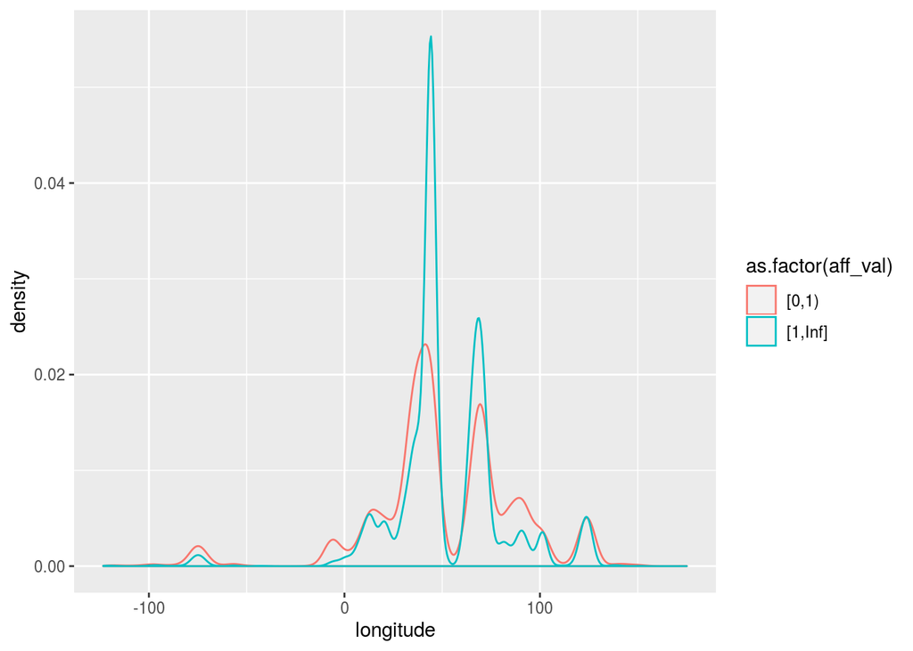

```r
ggplot(data=dOHECal) +
geom_density(aes(x=longitude,color=as.factor(aff_val)))
```

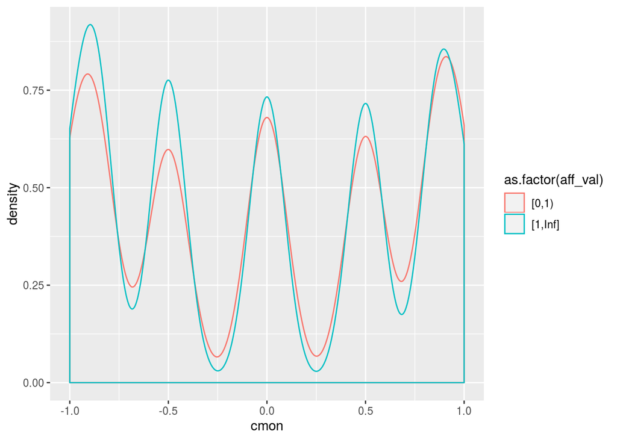

```r
ggplot(data=dOHECal) +
geom_density(aes(x=cmon,color=as.factor(aff_val)))
```

Above is the density graphs for longitude and for the cosine of the months. It can be seen that the longitude has some clear differences based on its position in the world. Where the cosine of the months doesn’t clearly.

Perform feature selection. In this case we will find the optimal number of features using grid search.

```r
# Take out columns that have just one level in the training set
not.to.use <- names(which((sapply(droplevels(dOHETrain[,catVars]),function(x)length(levels(x))))==1))
to.use <- c(catVars,numericVars)[!( c(catVars,numericVars) %in% not.to.use)]

# Compute the base rate of a saturation model
baseRateCheck <- logLikelyhood(dOHECal[,outcome],  sum(dOHECal[,outcome]==pos.label)/length(dOHECal[,outcome]) )


vars.likelihood.increase <- c()
## ------------------------------------------------------------------------

for(v in catVars[catVars%in%to.use]) {
  pii <- paste('pred',v,sep='')
  liCheck <- 2*((logLikelyhood(dOHECal[,outcome],dOHECal[,pii])
                 - baseRateCheck))
  vars.likelihood.increase[v] <- liCheck
}

## ------------------------------------------------------------------------

for(v in numericVars[numericVars%in%to.use]) {
  pii <- paste('pred',v,sep='')
  liCheck <- 2*((logLikelyhood(dOHECal[,outcome],dOHECal[,pii])
                 - baseRateCheck) - 1)
  vars.likelihood.increase[v] <- liCheck
}

vars.likelihood.increase <- sort(vars.likelihood.increase,decreasing = T)

## ------------------------------------------------------------------------
bestSelVars <- c()
bestAUC <- 0
for(i in seq(5, length(vars.likelihood.increase), by = 5))
{
  selVars <- names(vars.likelihood.increase)[1:i]
  selPredVars <-  paste('pred',selVars,sep='')
  minStep <- i

  fV <- paste(outcome,' ~ .')#,  paste(selVars, collapse=' + '), sep='')

  lrmodel <- glm(fV, data=dOHETrain[,c(outcome, selVars)], family = binomial)

  auc <- calcAUC(predict(lrmodel,newdata=dOHECal, type='response'), dOHECal[,outcome])

  print(sprintf("%d variables selected (at least %f increase in log likelihood). AUC: %f",
                length(selVars), vars.likelihood.increase[i], auc))
  if(auc>bestAUC){
    bestSelVars <- selVars
    bestAUC <- auc
  }
}
```

```
## [1] "5 variables selected (at least 886.940252 increase in log likelihood). AUC: 0.772133"
## [1] "10 variables selected (at least 623.507877 increase in log likelihood). AUC: 0.806829"
## [1] "15 variables selected (at least 255.027952 increase in log likelihood). AUC: 0.827680"
## [1] "20 variables selected (at least -10.824126 increase in log likelihood). AUC: 0.837839"
## [1] "25 variables selected (at least -167.516335 increase in log likelihood). AUC: 0.851627"
## [1] "30 variables selected (at least -313.621066 increase in log likelihood). AUC: 0.858260"
## [1] "35 variables selected (at least -363.789853 increase in log likelihood). AUC: 0.860925"
## [1] "40 variables selected (at least -377.340462 increase in log likelihood). AUC: 0.860528"
## [1] "45 variables selected (at least -421.410920 increase in log likelihood). AUC: 0.872614"
## [1] "50 variables selected (at least -431.204963 increase in log likelihood). AUC: 0.873944"
```

```
## [1] "55 variables selected (at least -456.605302 increase in log likelihood). AUC: 0.874820"
```

```
## [1] "60 variables selected (at least -472.503599 increase in log likelihood). AUC: 0.875201"
## [1] "65 variables selected (at least -485.249698 increase in log likelihood). AUC: 0.875000"
## [1] "70 variables selected (at least -488.353434 increase in log likelihood). AUC: 0.874815"
## [1] "75 variables selected (at least -495.174637 increase in log likelihood). AUC: 0.874983"
## [1] "80 variables selected (at least -502.200587 increase in log likelihood). AUC: 0.875322"
## [1] "85 variables selected (at least -504.997765 increase in log likelihood). AUC: 0.875116"
```

```
## [1] "90 variables selected (at least -506.255026 increase in log likelihood). AUC: 0.874819"
```

```
## [1] "95 variables selected (at least -510.130191 increase in log likelihood). AUC: 0.874799"
```

```
## [1] "100 variables selected (at least -517.141348 increase in log likelihood). AUC: 0.874650"
```

```
## [1] "105 variables selected (at least -528.283703 increase in log likelihood). AUC: 0.874973"
## [1] "110 variables selected (at least -545.369143 increase in log likelihood). AUC: 0.874810"
```

```
## [1] "115 variables selected (at least -557.428753 increase in log likelihood). AUC: 0.874756"
```

```
## [1] "120 variables selected (at least -615.466852 increase in log likelihood). AUC: 0.876494"
```

```
## [1] "125 variables selected (at least -735.885852 increase in log likelihood). AUC: 0.886325"
```

```
## [1] "130 variables selected (at least -823.610438 increase in log likelihood). AUC: 0.893033"
```

```r
selVars <- bestSelVars
```

This is very interesting and unexpected. It seemed like the optimal was about to be ~80 variables, but AUC started to increase again after 120 variables. Including all variables, even ones that are worse than random guessing, yields the best model, tested on the calibrations set.

### Logistic Regression model using One-Hot Encoding

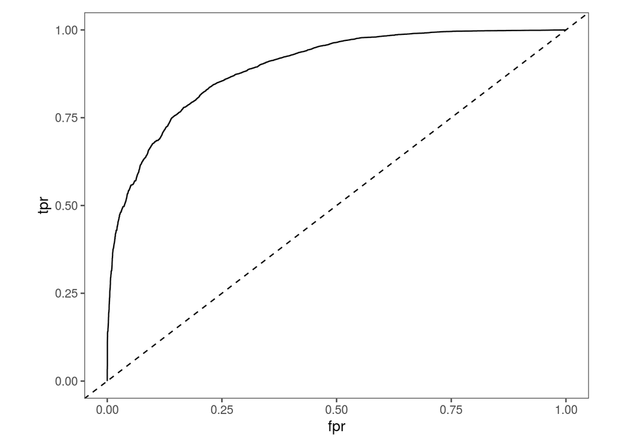

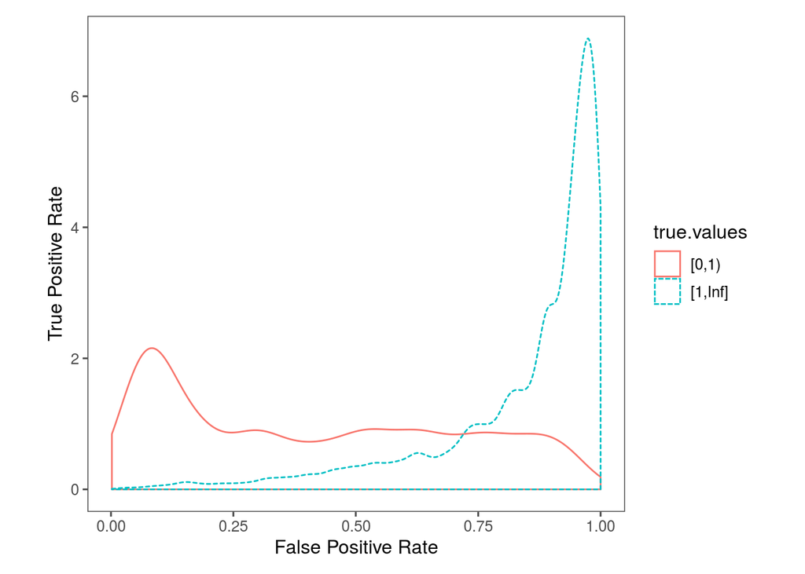

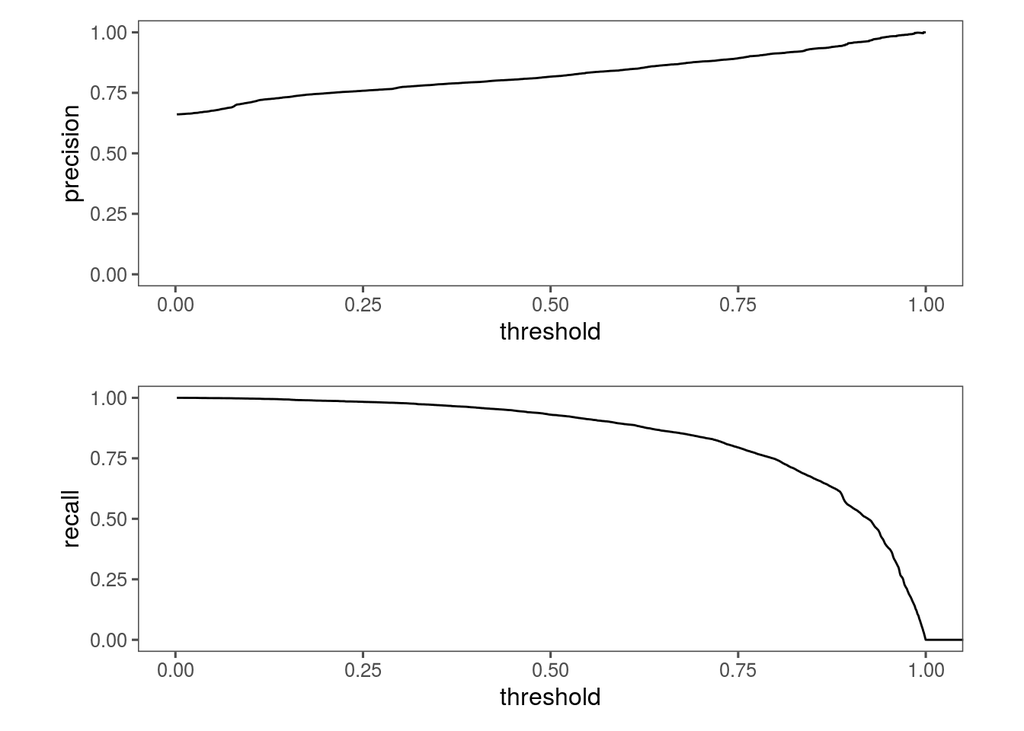

```
## Confusion Matrix
##
##          [0,1)   [1,Inf]
## ------  ------  --------
## FALSE     5690      1303
## TRUE      3895     17385
## [1] "Model Log Likelihood: NA"
## [1] "Null Model Log Likelihood: -18226.00342904"
```

|  | model.type | model.name | train.auc | cal.auc |
| --- | --- | --- | --- | --- |
| logreg.ohe.sel.vars | multivariate | logreg.ohe.sel.vars | 0.9074773 | 0.8930332 |

```r
fV <- paste(outcome,' ~ .')#,  paste(selVars, collapse=' + '), sep='')

logreg.ohe.sel.vars <- glm(fV, data=dOHETrain[,c(outcome, selVars)], family = binomial)
evaluate_and_log_model(model.type = 'multivariate',
                       model.name = 'logreg.ohe.sel.vars',
                       predictions.train = predict(logreg.ohe.sel.vars, newdata=dOHETrain, type = 'response'),
                       true.values.train = dOHETrain[,outcome],
                       predictions.cal = predict(logreg.ohe.sel.vars, newdata=dOHECal, type = 'response'),
                       true.values.cal = dOHECal[,outcome])
```

The ‘Logistic Regression model using One-Hot Encoding’ model doesn’t assign a log likelihood so we are unable to compare this metric. With an AUC of 0.91 (2.dp) for the training data and a value of 0.89 (2.dp) for the calibration data. This is an improvement compared to the decision trees and the logistic model. The ROC curve of this model looks comparable with the previous logistic model. The distribution of score broken up by known classes is clearly seperated . The precision looks good for the model as does the recall, with both improving.

### XGBOOST

Our final model is an XGBOOST

```r
tplan <- vtreat::designTreatmentsZ(dTrain, candidate.columns,
                                   minFraction= 0.025, # Restrict to levels with at least 2.5% of the instances
                                   verbose=FALSE)
# restrict to common varaibles types
# see vignette('vtreatVariableTypes', package = 'vtreat') for details
sf <- tplan$scoreFrame
newvars <- sf$varName[sf$code %in% c("lev", "clean", "isBAD")]

# Convert to matrix for XGBT to work
trainVtreat <- as.matrix(vtreat::prepare(tplan, dTrain, varRestriction = newvars))
calVtreat <- as.matrix(vtreat::prepare(tplan, dCal, varRestriction = newvars))
testVtreat <- as.matrix(vtreat::prepare(tplan, dTest, varRestriction = newvars))
```

```r
dim(trainVtreat)
```

```
## [1] 114148    111
```

```r
set.seed(0)
# estimate the optimal number of trees with cv in the training set
nrounds <- 1000
cv <- xgb.cv(data= trainVtreat,
             label= dTrain[,outcome]==pos.label,
             objective= 'binary:logistic',
             nrounds= nrounds,
             verbose= FALSE,
             early_stopping_rounds = 20, # stop searching if no improvement after 20 rounds
             nfold= 3,
             seed=0)

nrounds  <- which.min(cv$evaluation_log$test_error_mean) # classification
print(sprintf('Will use %d rounds, according to cv results', nrounds))
```

```
## [1] "Will use 205 rounds, according to cv results"
```

```r
xgbtmodel <- xgboost(data= trainVtreat,
                  label= dTrain[,outcome]==pos.label,
                 objective= 'binary:logistic',
                 nrounds= nrounds,
                 verbose= 0,
                 seed=0)
```

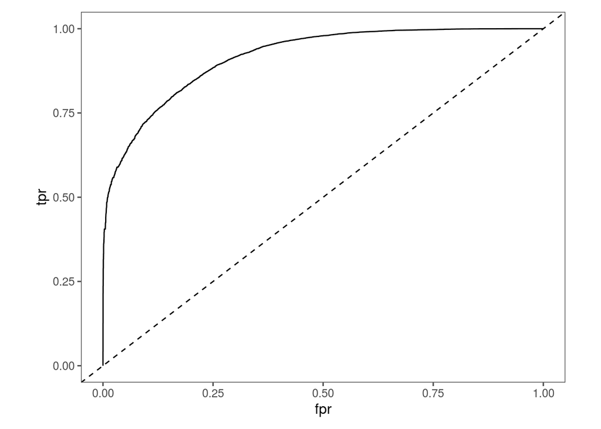

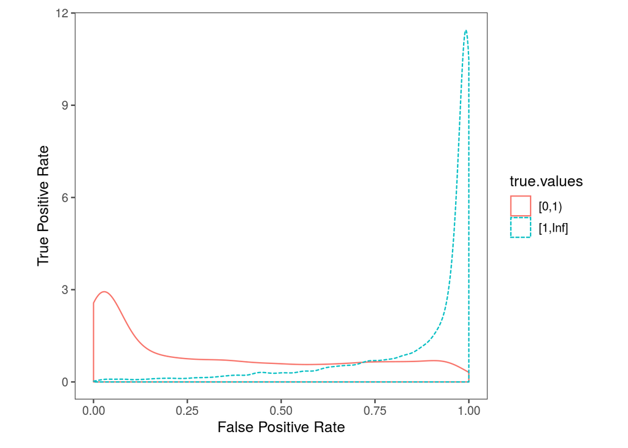

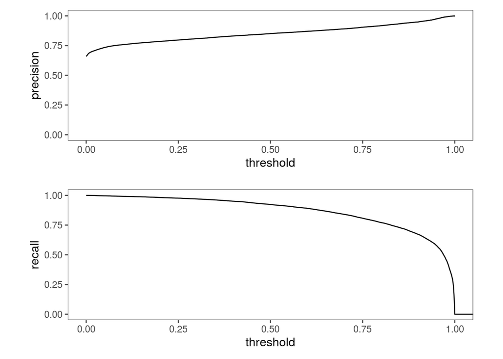

```
## Confusion Matrix
##
##          [0,1)   [1,Inf]
## ------  ------  --------
## FALSE     6631      1433
## TRUE      3031     17345
## [1] "Model Log Likelihood: -9872.08901527628"
## [1] "Null Model Log Likelihood: -18226.00342904"
```

|  | model.type | model.name | train.auc | cal.auc |
| --- | --- | --- | --- | --- |
| xgbtmodel | multivariate | xgbtmodel | 0.9643023 | 0.9166579 |

```r
evaluate_and_log_model(model.type = 'multivariate',
                       model.name = 'xgbtmodel',
                       predictions.train = predict(xgbtmodel,trainVtreat),
                       true.values.train = dTrain[,outcome],
                       predictions.cal = predict(xgbtmodel,calVtreat),
                       true.values.cal = dCal[,outcome])
```

### Compare all models

Top 10 models

```r
kable(head(models.auc[order(models.auc$cal.auc, decreasing = T), ], 10))
```

|  | model.type | model.name | train.auc | cal.auc |
| --- | --- | --- | --- | --- |
| xgbtmodel | multivariate | xgbtmodel | 0.9643023 | 0.9166579 |
| logreg.ohe.sel.vars | multivariate | logreg.ohe.sel.vars | 0.9074773 | 0.8930332 |
| logreg.sel.pred.vars | multivariate | logreg.sel.pred.vars | 0.8874630 | 0.8685504 |
| decision.tree.all.vars | multivariate | decision.tree.all.vars | 0.8246138 | 0.7998543 |
| decision.tree.sel.vars | multivariate | decision.tree.sel.vars | 0.8233864 | 0.7975730 |
| targsubtype1_txt | univariate | targsubtype1_txt | 0.7874123 | 0.7310866 |
| country_txt | univariate | country_txt | 0.7299450 | 0.6919072 |
| natlty1_txt | univariate | natlty1_txt | 0.7288547 | 0.6858629 |
| targtype1_txt | univariate | targtype1_txt | 0.7239635 | 0.6811225 |
| attacktype1_txt | univariate | attacktype1_txt | 0.7431663 | 0.6689829 |

Comparing all of the evaluation data from all of the models it can be seen that the ‘XGBOOST’ (xgbtmodel) model has out performed the other models in all metrics.

ROC Curves

```r
xgb.pred <- prediction(predict(xgbtmodel,calVtreat), dCal[,outcome])
logreg.ohe.pred <- prediction(predict(logreg.ohe.sel.vars, newdata=dOHECal, type = 'response'), dCal[,outcome])
```

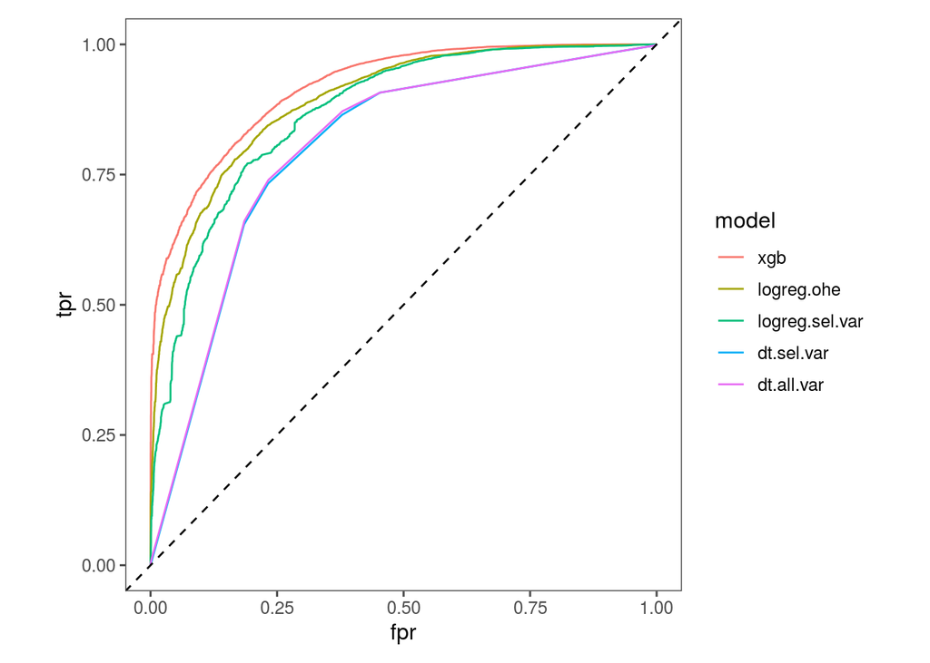

```r
logreg.sel.var.pred <- prediction(predict(logreg.sel.pred.vars, newdata=dCal, type = 'response') , dCal[,outcome])
dt.sel.var.pred <- prediction(predict(decision.tree.sel.vars, newdata=dCal)[,pos.label] , dCal[,outcome])
dt.all.var.pred <- prediction(predict(decision.tree.all.vars, newdata=dCal)[,pos.label], dCal[,outcome])

preds <- list(xgb.pred, logreg.ohe.pred, logreg.sel.var.pred, dt.sel.var.pred, dt.all.var.pred)
model.names <- c('xgb', 'logreg.ohe', 'logreg.sel.var', 'dt.sel.var', 'dt.all.var')
roc.df <- data.frame()
for(i in 1:length(model.names)){
  pred <- preds[[i]]
  model.name <- model.names[i]
  perf <- performance( pred, "tpr", "fpr" )
  roc.df <- rbind(roc.df, data.frame(
               'fpr'=unlist(perf@x.values),
               'tpr'=unlist(perf@y.values),
               'threshold'=unlist(perf@alpha.values),
               'model'=model.name))
}

ggplot(roc.df, aes(x=fpr, y=tpr, group=model, color=model))+
  geom_line() +
  geom_abline(intercept = 0, slope = 1, linetype='dashed') +
  cits4009_theme
```

Looking at the ROC graphs it is clear to see that our best model is the xgboost.

### Evaluate selected model on the Test set

The ‘XGBOOST’ model will be used on the test data to see how well it performs.

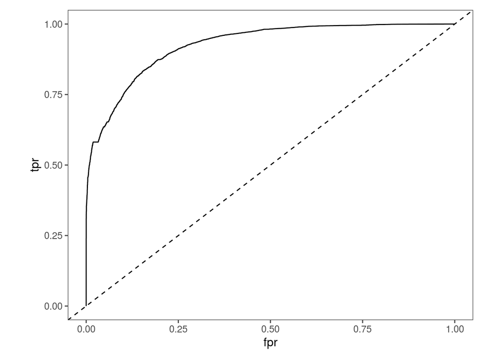

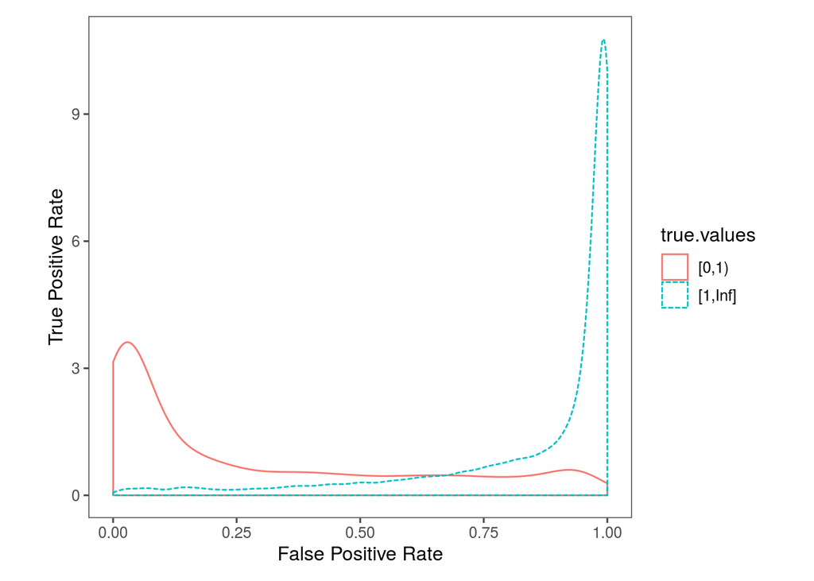

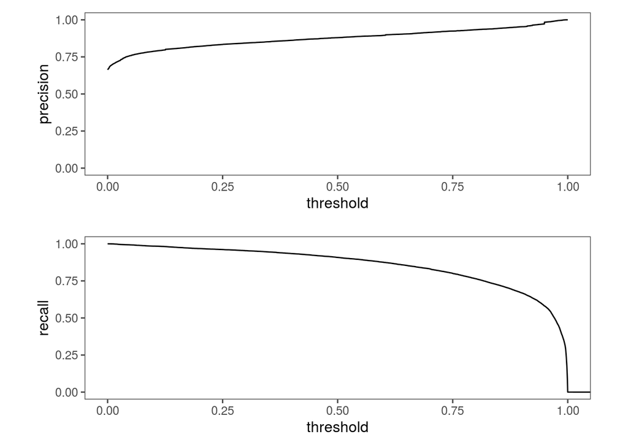

```
## Confusion Matrix
##
##          [0,1)   [1,Inf]
## ------  ------  --------
## FALSE     5623      1358
## TRUE      1833     13415
## [1] "Model Log Likelihood: -7309.92655427438"
## [1] "Null Model Log Likelihood: -14180.9721968185"
```

```
## [1] 0.9257771
```

```r
evaluate_performance(predict(xgbtmodel,testVtreat), dTest[,outcome], do.print=TRUE, threshold.value=0.5, pos=pos.label)
```

## Part 2 - Clustering

We will cluster the “groups” perpetrating the attacks. To this end, we will consider their way of opperation (what type of attacks they make), their location (in which regions they attack), and the lethality of their attacks. Since we care about the relative percentages and not so much about absolute values, we use the cosine similarity. We first calculate the pairwise similarity in each of these three categories, and then create a weighted average to define the similiarity between groups. Since we are working with a distance matrix, we use hierarchical clustering. Note that we will only keep groups with at least 100 attacks on record.

Load some extra libraries

```r
library(scales)
library(fpc)
devtools::install_github("ricardo-bion/ggradar", dependencies=TRUE)
library(ggradar)
```

```r
attacks <- read.csv(data.path)
```

We define some helper functions

```r
# This function "pivots" a categorical field, grouped by the perpetrating "group"
get.group.actions.pivoted <- function(field, min_count=100){
  field <- as.character(field)
  group.actions <-  attacks %>%
                    filter(gname != 'Unknown') %>%
                    filter(attacktype1_txt != 'Unknown') %>%
                    group_by(.dots=c('gname',field)) %>%
                    summarise(cnt = n()) %>%
                    spread(field, cnt, fill = 0) %>%
                    as.data.frame()
  row.names(group.actions) <- group.actions$gname
  group.actions$gname <- NULL
  group.actions[rowSums(group.actions, na.rm=TRUE) > min_count,]

}

# A cosine distance (1 - cosine_similarity) matrix calculation
cos.dist <- function(DF){
  Matrix <- as.matrix(DF)
  sim <- Matrix / sqrt(rowSums(Matrix * Matrix))
  sim <- sim %*% t(sim)
  rownames(sim)<-rownames(DF)
  as.dist(1 - sim)
}

# Will use this for plotting (categorical colors)
gg_color_hue <- function(n) {
  hues = seq(15, 375, length = n + 1)
  hcl(h = hues, l = 65, c = 100)[1:n]
}
```

Categorize the number of individuals killed

```r
attacks$nkill_ctg <- 'UNK'
attacks$nkill_ctg[attacks$nkill==0] <- '0'
attacks$nkill_ctg[attacks$nkill>0 & attacks$nkill<=10] <- '1-10'
attacks$nkill_ctg[attacks$nkill>10 & attacks$nkill<=50] <- '11-50'
attacks$nkill_ctg[attacks$nkill>50] <- '>50'
attacks$nkill_ctg <- as.factor(attacks$nkill_ctg)
```

Configure how we are going to combine the distances

```r
configuration <- data.frame(field  = c('region_txt', 'attacktype1_txt', 'nkill_ctg'),
                            weight = c( 0.3       ,  0.4             ,  0.3))

pivoted.data <- lapply(configuration$field, get.group.actions.pivoted)
names(pivoted.data) <- configuration$field
```

The resulting tables look like this:

```r
kable(head(pivoted.data[['region_txt']]))
```

|  | Australasia & Oceania | Central America & Caribbean | Central Asia | East Asia | Eastern Europe | Middle East & North Africa | North America | South America | South Asia | Southeast Asia | Sub-Saharan Africa | Western Europe |
| --- | --- | --- | --- | --- | --- | --- | --- | --- | --- | --- | --- | --- |
| Abu Sayyaf Group (ASG) | 0 | 0 | 0 | 0 | 0 | 0 | 0 | 0 | 0 | 519 | 0 | 0 |
| African National Congress (South Africa) | 0 | 0 | 0 | 0 | 0 | 0 | 0 | 0 | 0 | 0 | 522 | 1 |
| Al-Aqsa Martyrs Brigade | 0 | 0 | 0 | 0 | 0 | 171 | 0 | 0 | 0 | 0 | 0 | 0 |
| Al-Gama’at al-Islamiyya (IG) | 0 | 0 | 0 | 0 | 1 | 254 | 0 | 0 | 0 | 0 | 1 | 0 |
| Algerian Islamic Extremists | 0 | 0 | 0 | 0 | 0 | 352 | 0 | 0 | 0 | 0 | 0 | 0 |
| Allied Democratic Forces (ADF) | 0 | 0 | 0 | 0 | 0 | 0 | 0 | 0 | 0 | 0 | 176 | 0 |

```r
kable(head(pivoted.data[['attacktype1_txt']]))
```

|  | Armed Assault | Assassination | Bombing/Explosion | Facility/Infrastructure Attack | Hijacking | Hostage Taking (Barricade Incident) | Hostage Taking (Kidnapping) | Unarmed Assault |
| --- | --- | --- | --- | --- | --- | --- | --- | --- |
| Abu Sayyaf Group (ASG) | 99 | 16 | 209 | 4 | 10 | 2 | 179 | 0 |
| African National Congress (South Africa) | 53 | 70 | 398 | 1 | 0 | 0 | 0 | 1 |
| Al-Aqsa Martyrs Brigade | 66 | 5 | 87 | 4 | 0 | 1 | 7 | 1 |
| Al-Gama’at al-Islamiyya (IG) | 107 | 125 | 14 | 10 | 0 | 0 | 0 | 0 |
| Algerian Islamic Extremists | 110 | 13 | 219 | 2 | 0 | 0 | 8 | 0 |
| Allied Democratic Forces (ADF) | 110 | 8 | 10 | 5 | 0 | 1 | 42 | 0 |

```r
kable(head(pivoted.data[['nkill_ctg']]))
```

|  | 0 | 1-10 | 11-50 | >50 | UNK |
| --- | --- | --- | --- | --- | --- |
| Abu Sayyaf Group (ASG) | 305 | 172 | 8 | 2 | 32 |
| African National Congress (South Africa) | 338 | 140 | 6 | 1 | 38 |
| Al-Aqsa Martyrs Brigade | 56 | 99 | 4 | 0 | 12 |
| Al-Gama’at al-Islamiyya (IG) | 58 | 192 | 5 | 1 | 0 |
| Algerian Islamic Extremists | 162 | 182 | 6 | 0 | 2 |
| Allied Democratic Forces (ADF) | 17 | 116 | 28 | 1 | 14 |

Calculate the cosine distances for each of the 3 groups of categorical variables

```r
cosine.distances <- lapply(pivoted.data, cos.dist )
```

Build a single distance matrix according to the “weights” in the configuration

```r
get.weighted.dist <- function(i){
  dw <- cosine.distances[[i]]*configuration$weight[i]
  dw[is.na(dw)] <- 1
  dw
}
d <- get.weighted.dist(1)
for(i in 2:nrow(configuration)){
  d <- d +  get.weighted.dist(i)
}
```

Build a hierarchical cluster with the obtained distance matrix

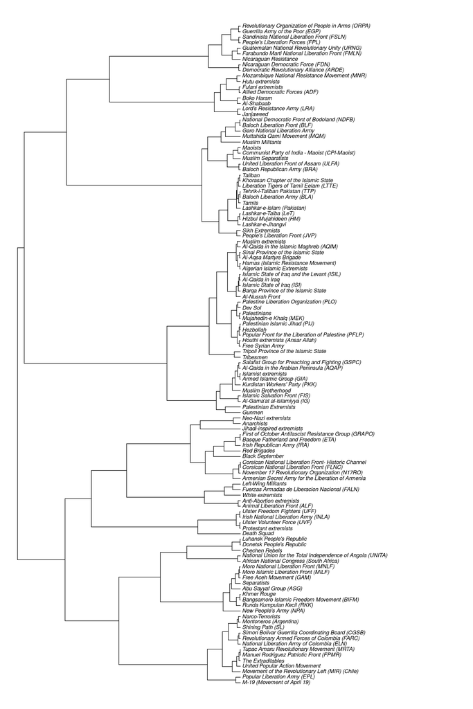

```r
hfit <- hclust(d, method = 'ward.D2')
par(mar = c(0, 0, 0, 0))
plot(as.phylo(hfit), cex = 0.7, label.offset = 0.01)
```

Print the names of the groups in each cluster. We choose 5 clusters after analyzing the results. This is explained further in the notebook.

```r
clusters <- as.factor(cutree(hfit, 5))
print_clusters<-function(clusters){
  for(i in 1:length(levels(clusters))){
    cat(paste0('Cluster ',i,':\n'))
    cat(paste(names(clusters[clusters == i]), collapse = "\t"))
    cat('\n\n')
  }
}
print_clusters(clusters)
```

```
## Cluster 1:
## Abu Sayyaf Group (ASG)   African National Congress (South Africa)    Bangsamoro Islamic Freedom Movement (BIFM)  Chechen Rebels  Donetsk People's Republic   Free Aceh Movement (GAM)    Khmer Rouge Luhansk People's Republic   M-19 (Movement of April 19) Manuel Rodriguez Patriotic Front (FPMR) Mont…
##
## Cluster 2:
## Al-Aqsa Martyrs Brigade  Al-Gama'at al-Islamiyya (IG)    Algerian Islamic Extremists Al-Nusrah Front Al-Qaida in Iraq    Al-Qaida in the Arabian Peninsula (AQAP)    Al-Qaida in the Islamic Maghreb (AQIM)  Armed Islamic Group (GIA)   Barqa Province of the Islamic State Dev Sol Free Syrian Army    …
##
## Cluster 3:
## Allied Democratic Forces (ADF)   Al-Shabaab  Boko Haram  Democratic Revolutionary Alliance (ARDE)    Farabundo Marti National Liberation Front (FMLN)    Fulani extremists   Guatemalan National Revolutionary Unity (URNG)  Guerrilla Army of the Poor (EGP)    Hutu extremists Janjaweed   Lord's Resis…
##
## Cluster 4:
## Anarchists   Animal Liberation Front (ALF)   Anti-Abortion extremists    Armenian Secret Army for the Liberation of Armenia  Basque Fatherland and Freedom (ETA) Black September Corsican National Liberation Front (FLNC)   Corsican National Liberation Front- Historic Channel    Death Squad First of…
##
## Cluster 5:
## Baloch Liberation Army (BLA) Baloch Liberation Front (BLF)   Baloch Republican Army (BRA)    Communist Party of India - Maoist (CPI-Maoist)  Garo National Liberation Army   Hizbul Mujahideen (HM)  Khorasan Chapter of the Islamic State   Lashkar-e-Islam (Pakistan)  Lashkar-e-Jhangvi   Lashkar-e-Ta…
```

Number of groups in each cluster

```r
kable(table(clusters))
```

| clusters | Freq |
| --- | --- |
| 1 | 27 |
| 2 | 32 |
| 3 | 17 |
| 4 | 22 |
| 5 | 22 |

Analize Cluster stability with boostrapping

```r
summary(cboot.hclust$result)
```

```
##               Length Class  Mode
## result          7    hclust list
## noise           1    -none- logical
## nc              1    -none- numeric
## clusterlist     5    -none- list
## partition     120    -none- numeric
## clustermethod   1    -none- character
## nccl            1    -none- numeric
```

```r
groups <- as.factor(cboot.hclust$result$partition)

cat('\nStability:\n')
```

```
##
## Stability:
```

```r
1-cboot.hclust$bootbrd/100
```

```
## [1] 0.95 1.00 0.58 0.75 0.95
```

Now we check the optimal number of clusters using the Calinski-Harabasz (CH) criteria

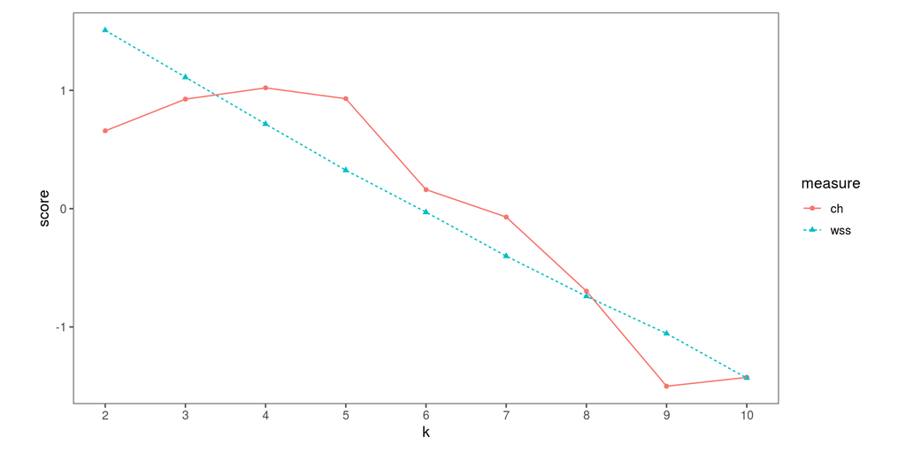

```r
## ------------------------------------------------------------------------
# Function to calculate squared distance
# between two vectors x and y
sqr_edist <- function(x, y) {
  sum((x-y)^2)
}

## Fucntion to calculate WSS of a cluster
wss.cluster <- function(clustermat) {
  c0 <- apply(clustermat, 2, FUN=mean)
  sum(apply(clustermat, 1,
            FUN=function(row){sqr_edist(row,c0)}))
}

## ------------------------------------------------------------------------
wss.total <- function(dmatrix, labels) {
  wsstot <- 0
  k <- length(unique(labels))
  for(i in 1:k){
    wsstot <- wsstot +
      wss.cluster(subset(dmatrix, labels==i))
  }
  wsstot
}

## ------------------------------------------------------------------------
totss <- function(dmatrix) {
  grandmean <- apply(dmatrix, 2, FUN=mean)
  sum(apply(dmatrix, 1,
            FUN=function(row){
              sqr_edist(row, grandmean)
              }
            )
      )
}


## ----mysize=TRUE, size='\\tiny'------------------------------------------
ch_criterion <- function(dmatrix, d, kmax, method="kmeans") {
  if(!(method %in% c("kmeans", "hclust"))){
    stop("method must be one of c('kmeans', 'hclust')")
  }
  npts <- dim(dmatrix)[1] # number of rows.
  totss <- totss(dmatrix)
  wss <- numeric(kmax)
  crit <- numeric(kmax)
  wss[1] <- (npts-1)*sum(apply(dmatrix, 2, var))
  for(k in 2:kmax) {
    if(method=="kmeans") {
      clustering<-kmeans(dmatrix, k, nstart=10, iter.max=100)
      wss[k] <- clustering$tot.withinss
    }else { # hclust
      #d <- dist(dmatrix, method="euclidean")
      pfit <- hclust(d, method="ward.D2")
      labels <- cutree(pfit, k=k)
      wss[k] <- wss.total(dmatrix, labels)
    }
  }
  bss <- totss - wss
  crit.num <- bss/(0:(kmax-1))
  crit.denom <- wss/(npts - 1:kmax)
  crit.num[1] <- 1
  list(crit = (crit.num/crit.denom)[2:kmax], wss = wss[2:kmax], totss = totss[2:kmax], bss = bss[2:kmax])
}

## ------------------------------------------------------------------------

# We use Single Value Decomposition (SVD) to transform the similarity matrix into a feature space
# so that we can calculate the WSS, BSS and tot SS with this proxy
pmatrix <- t(svd(d)$v)[,1:100]

kmax <- 10
clustcrit <- ch_criterion(pmatrix, d, kmax, method="hclust")

critframe <- data.frame(k=2:kmax, ch=scale(clustcrit$crit),
                        wss=scale(clustcrit$wss))

critframe <- melt(critframe, id.vars=c("k"),
                  variable.name="measure",
                  value.name="score")

ggplot(critframe, aes(x=k, y=score, color=measure)) +
  geom_point(aes(shape=measure)) +
  geom_line(aes(linetype=measure)) +
  scale_x_continuous(breaks=2:kmax, labels=2:kmax) +
  cits4009_theme
```

The CH is maximized at 4 clusters. There is no clear “elbow” in the WSS curve. Our choice of 5 clusters seems reasonable.

### Analyze cluster results

First we will use PCA for the “attack type” and “number of killed” group of variables and see where the mean of each cluster lies

```r
plot_pca_clusters <- function(variable_type = 'attacktype1_txt'){

  # Scale each row to be in percentages of the group
  group.percentages <- 100*pivoted.data[[variable_type]]/rowSums(pivoted.data[[variable_type]])

  fit <- prcomp(group.percentages, scale=T)
  pca.data <- data.frame(row.names=row.names(fit$x), fit$x[,1:2])
  pca.data$cluster <- clusters

  cluster.centroids <- pca.data %>% group_by(cluster) %>% summarise_all(mean)
  pca.data$name <- row.names(pca.data)

  x="PC1"
  y="PC2"
  PC<-fit
  # PC being a prcomp object
  data <- cluster.centroids
  plot <- ggplot(data, aes_string(x=x, y=y)) +
          geom_point(alpha=1, size=8, aes(color=cluster)) +
          geom_text(alpha=1, size=5, aes(label=cluster), color='black')
  plot <- plot + geom_point(data=pca.data, mapping=aes_string(x=x, y=y, color='cluster'), alpha=0.5, size=3)
  plot <- plot + geom_hline(aes(yintercept=0), size=.2) + geom_vline(aes(xintercept=0), size=.2)
  datapc <- data.frame(varnames=rownames(PC$rotation), PC$rotation)
  mult <- min(
      (max(data[,y]) - min(data[,y])/(max(datapc[,y])-min(datapc[,y]))),
      (max(data[,x]) - min(data[,x])/(max(datapc[,x])-min(datapc[,x])))
      )
  datapc <- transform(datapc,
          v1 = 2.25 * mult * (get(x)),
          v2 = 2.25 * mult * (get(y))
          )
  plot <- plot + coord_equal() + geom_text(data=datapc, aes(x=v1, y=v2, label=varnames), size = 5, vjust=1, color="red")
  plot <- plot + geom_segment(data=datapc, aes(x=0, y=0, xend=v1, yend=v2), arrow=arrow(length=unit(0.2,"cm")), alpha=0.75, color="red")
  plot <- plot + ggtitle(paste("PCA for",variable_type))
  plot <- plot + cits4009_theme
  #plot <- plot + scale_x_continuous(limits = c(-3,3))
  plot
}
```

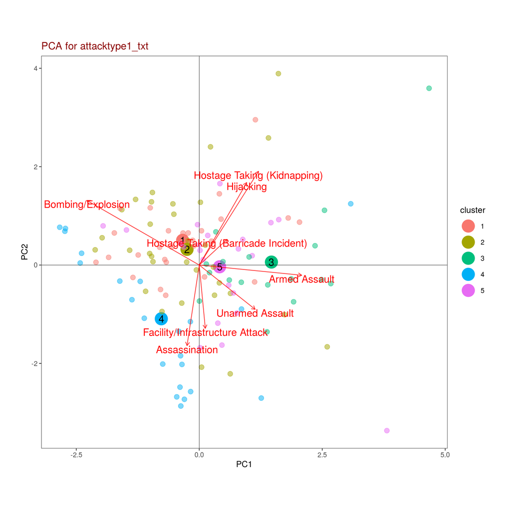

```r
plot_pca_clusters('attacktype1_txt')
```

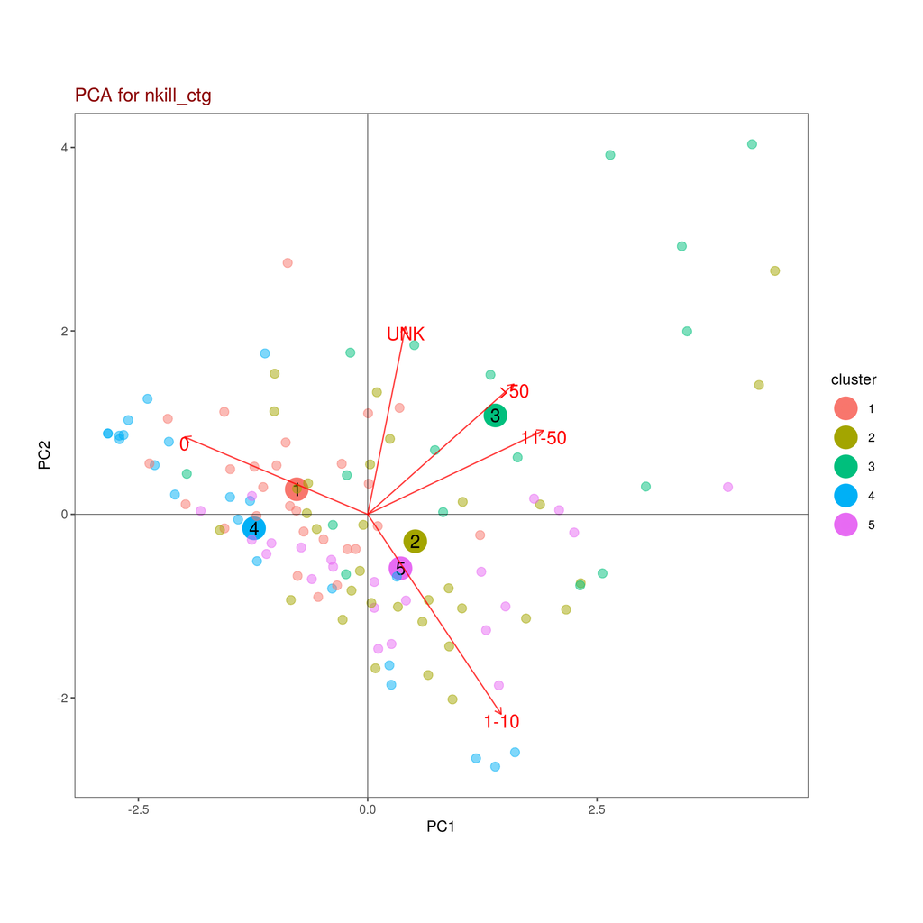

```r
plot_pca_clusters('nkill_ctg')
```

Now we will analyze the locations where the attacks from each cluster were perpetrated

```r
clusters_df <- as.data.frame(clusters)
names(clusters_df) <- 'cluster'
clusters_df$gname <- as.factor(rownames(clusters_df))
```

```r
attacks.clusterized <- inner_join(attacks, clusters_df, by='gname')
```

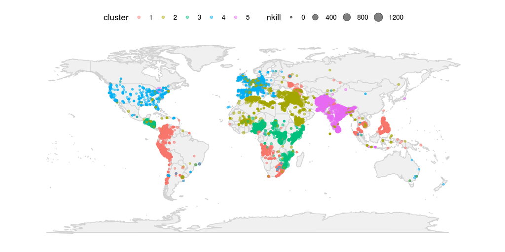

```r
ggplot(attacks.clusterized) +
  geom_polygon(data=map_data("world"), aes(x = long, y = lat, group = group), fill="#F0F0F0", colour = "lightgray")+
  geom_point(aes(x=longitude, y=latitude, color=cluster, size=nkill), alpha=0.5) +
  coord_quickmap() +
  cits4009_map_theme
```

Western Europe and North America have the highest prevalence of “cluster 4” attacks Central America and Central Africa have the highest prevalence of “cluster 3” attacks South America, South of Africa and South East Asia have the highest prevalence of “cluster 1” attacks India and Pakistan have the highest prevalence of “cluster 5” attacks North Africa and Middle East have the highest prevalence of “cluster 2” attacks

#### Clusters profiling

Even though the previous analyisis have enough information to distinguish the clusters, we will profile each cluster using radar charts and a summary table. They show a clear picture of the results

Based on the correlations we see from the PCA chart, we will group some columns: * Both Hostage Taking and Hijacking * Armed Assault and Unarmed Assault

Calculate by Attack type

```r
df <- pivoted.data[['attacktype1_txt']]
df$cluster <- clusters
df <- df %>% group_by(cluster) %>% summarise_all(mean)
df$cluster <- NULL
df <- round(100*df/rowSums(df))
df$Hostage<- df$Hijacking+df$`Hostage Taking (Barricade Incident)`+df$`Hostage Taking (Kidnapping)`
df$Assault <- df$`Armed Assault` + df$`Unarmed Assault`
df <- df[,c('Bombing/Explosion','Hostage','Assault','Facility/Infrastructure Attack', 'Assassination')]
colnames(df) <- c('Bombing','Hostage','Assault','Facility', 'Assassination')
table.attack.type <- kable(df, row.names = T)


radar.attack.type <- ggradar(df %>% rownames_to_column(var="group") %>% mutate_at(vars(-group),funs(rescale)),
        group.point.size = 2,
        grid.label.size = 0,
        group.colours=gg_color_hue(5),
        legend.position='none',
        plot.extent.x.sf=1.5,
        plot.title='Attack Type') + cits4009_radar_theme
```

Calculate by number of killed category

```r
df <- pivoted.data[['nkill_ctg']]
df$cluster <- clusters
df <- df %>% group_by(cluster) %>% summarise_all(mean)
df$cluster <- NULL
df <- round(100*df/rowSums(df))
table.nkill.ctg <- kable(df, row.names = T)

radar.nkill.ctg <- ggradar(df %>% rownames_to_column(var="group") %>% mutate_at(vars(-group),funs(rescale)),
        group.point.size = 2,
        grid.label.size = 0,
        group.colours=gg_color_hue(5),
        legend.position='none',
        plot.extent.x.sf=1.5,
        plot.title='Kill Category') + cits4009_radar_theme
```

Calculate by region

```r
df <- pivoted.data[['region_txt']]
df$cluster <- clusters
df <- df %>% group_by(cluster) %>% summarise_all(mean)
df$cluster <- NULL
df <- round(100*df/rowSums(df))
# Change the order of the columns so that it looks better in the radial chart
df <- df[,c("Australasia & Oceania", "Eastern Europe", "Western Europe", "North America",
            "Central America & Caribbean", "South America",
            "Sub-Saharan Africa", "Middle East & North Africa",
            "Central Asia", "East Asia", "South Asia", "Southeast Asia")]
table.region <- kable(df, row.names = T)
radar.region <- ggradar(df %>% rownames_to_column(var="group") %>% mutate_at(vars(-group),funs(rescale)),
        group.point.size = 2,
        grid.label.size = 0,
        group.colours=gg_color_hue(5),
        legend.position='right',
        plot.extent.x.sf=1.5,
        plot.title='Region') + cits4009_radar_theme
```

Now we show everything

```r
table.attack.type
```

|  | Bombing | Hostage | Assault | Facility | Assassination |
| --- | --- | --- | --- | --- | --- |
| 1 | 46 | 9 | 28 | 5 | 11 |
| 2 | 54 | 9 | 24 | 4 | 9 |
| 3 | 33 | 9 | 48 | 4 | 6 |
| 4 | 46 | 3 | 12 | 11 | 29 |
| 5 | 41 | 10 | 33 | 6 | 9 |

```r
table.nkill.ctg
```

|  | 0 | 1-10 | 11-50 | >50 | UNK |
| --- | --- | --- | --- | --- | --- |
| 1 | 56 | 34 | 4 | 0 | 7 |
| 2 | 36 | 50 | 7 | 1 | 7 |
| 3 | 32 | 40 | 9 | 1 | 18 |
| 4 | 58 | 37 | 0 | 0 | 5 |
| 5 | 36 | 55 | 6 | 1 | 2 |

```r
table.region
```

|  | Australasia & Oceania | Eastern Europe | Western Europe | North America | Central America & Caribbean | South America | Sub-Saharan Africa | Middle East & North Africa | Central Asia | East Asia | South Asia | Southeast Asia |
| --- | --- | --- | --- | --- | --- | --- | --- | --- | --- | --- | --- | --- |
| 1 | 0 | 6 | 0 | 0 | 0 | 62 | 5 | 0 | 0 | 0 | 1 | 26 |
| 2 | 0 | 0 | 2 | 0 | 0 | 0 | 1 | 95 | 0 | 0 | 1 | 1 |
| 3 | 0 | 0 | 0 | 0 | 44 | 0 | 56 | 0 | 0 | 0 | 0 | 0 |
| 4 | 0 | 0 | 86 | 8 | 2 | 2 | 0 | 1 | 0 | 0 | 0 | 0 |
| 5 | 0 | 0 | 0 | 0 | 0 | 0 | 0 | 1 | 0 | 0 | 99 | 1 |

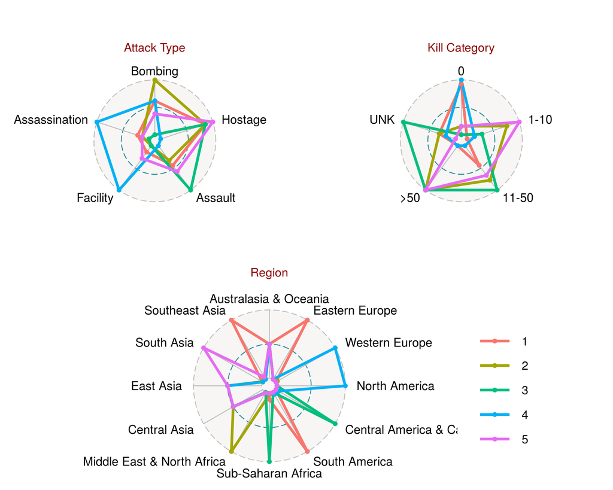

```r
grid.arrange(radar.attack.type, radar.nkill.ctg, radar.region, heights = c(1.2, 1),
              layout_matrix = rbind(c(1, 2),  c(3, 3)))
```

These are the 5 groups in each cluster with the most attacks

```r
kable(
attacks.clusterized %>% group_by(.dots=c('gname','cluster')) %>%
                    summarise(cnt = n()) %>%
                    group_by(.dots=c('cluster')) %>%
                    mutate(cluster_rank = order(order(cnt, decreasing=TRUE))) %>%
                    filter(cluster_rank<=5) %>%
                    arrange(cluster, cluster_rank)
)
```

| gname | cluster | cnt | cluster_rank |
| --- | --- | --- | --- |
| Shining Path (SL) | 1 | 4555 | 1 |
| New People’s Army (NPA) | 1 | 2772 | 2 |
| Revolutionary Armed Forces of Colombia (FARC) | 1 | 2487 | 3 |
| National Liberation Army of Colombia (ELN) | 1 | 1561 | 4 |
| Manuel Rodriguez Patriotic Front (FPMR) | 1 | 830 | 5 |
| Islamic State of Iraq and the Levant (ISIL) | 2 | 5613 | 1 |
| Kurdistan Workers’ Party (PKK) | 2 | 2310 | 2 |
| Palestinians | 2 | 1125 | 3 |
| Houthi extremists (Ansar Allah) | 2 | 1062 | 4 |
| Al-Qaida in the Arabian Peninsula (AQAP) | 2 | 1020 | 5 |
| Farabundo Marti National Liberation Front (FMLN) | 3 | 3351 | 1 |
| Al-Shabaab | 3 | 3288 | 2 |
| Boko Haram | 3 | 2418 | 3 |
| Nicaraguan Democratic Force (FDN) | 3 | 895 | 4 |
| Fulani extremists | 3 | 511 | 5 |
| Irish Republican Army (IRA) | 4 | 2671 | 1 |
| Basque Fatherland and Freedom (ETA) | 4 | 2024 | 2 |
| Corsican National Liberation Front (FLNC) | 4 | 639 | 3 |
| Protestant extremists | 4 | 334 | 4 |
| Death Squad | 4 | 326 | 5 |
| Taliban | 5 | 7478 | 1 |
| Communist Party of India - Maoist (CPI-Maoist) | 5 | 1878 | 2 |
| Maoists | 5 | 1630 | 3 |
| Liberation Tigers of Tamil Eelam (LTTE) | 5 | 1606 | 4 |
| Tehrik-i-Taliban Pakistan (TTP) | 5 | 1351 | 5 |

## Conclusions

We’ve used the Global Terrorist Database to fit a predictive classifier that, given an attack information, can decide if people were killed or injured by it. We validated the performance on an out-of-time split of the data. Additionally, we proposed a clustering for the groups perpetrating these acts, based on the way they operate and their locations. When looking at the groups in each cluster and their characteristics, the cluster seems reasonable, and many groups that are known to be similar in motivation and way of operating are grouped together. A possible next step would be to use the group cluster information as a feature for the classifier, since it might encode useful information without the need of having too many levels in the “group” feature.